# Appendix A

This report narrates the process of factor analizing the proposed scale, eliminating items, and fitting the resulting scale to a confirmatory model.

```r
library(magrittr) # enables piping : %>%
library(psych)
library(ggplot2)# graphing
library(sem)
library(GPArotation)
requireNamespace("readr")   # data input
requireNamespace("tidyr")   # data manipulation
requireNamespace("dplyr")   # Avoid attaching dplyr, b/c its function names conflict with a lot of packages (esp base, stats, and plyr).
requireNamespace("testit")  # For asserting conditions meet expected patterns.
requireNamespace("readxl") # for inputing Excel files
```

```r
source("./shinyApp/sourced/SteigerRLibraryFunctions.txt")
source("./shinyApp/sourced/AdvancedFactorFunctions_CF.R")
source("./scripts/common-functions.R") # used in multiple reports
source("./scripts/graph-presets.R") # fonts, colors, themes
source("./scripts/fa-utility-functions.R") # to graph factor patterns
```

```r
sample_size <- 643
opt <- options(fit.indices = c("GFI", "AGFI", "RMSEA", "NFI", "NNFI", "CFI", "RNI", "IFI", "SRMR", "AIC", "AICc", "BIC", "CAIC"))
```

```r
dto <- readRDS("./data/unshared/derived/dto.rds")
unitData <- dto$unitData
metaData <- dto$metaData
ds <- dto$analytic
```

# Introduction

The purpose of this research was to develop a new measure of fear of childbirth (the Childbirth Fear Questionnaire; CFQ) that would address the limitations of existing measures. Participants were 643 pregnant women residing in English speaking countries, and were recruited via online forums. Participants completed a set of questionnaires, including the CFQ, via an online survey.

The administered CFQ contained 49 items grouped into 9 subgroups. The review of items on the questionnaire, their descriptive statistics, and group correlations are available in the [Appendix C](https://rawgit.com/andkov/fear-of-childbirth/master/reports/appendix-c/appendix-c.html).

# Overview

This section give a summary of the steps applied during the analysis.

By comparing various rotations and considering interpretive qualities of the solutions, we have decided to use orthogonal bifactor rotation, as the one that offers the greatest interpretability. To examine the various solutions in details consult [Appendix B](https://rawgit.com/andkov/fear-of-childbirth/master/reports/appendix-b/appendix-b-0.html)

## Analysis Steps

The following steps are repeated for each of the analytic phases:

#### 1.Scree

Scree plot is plotted and top eigen values are displayed

#### 2.MAP

`psych::nfactors` call is applied, producing Very Simple Structure, Velicer’s MAP, and other criteria to determine the appropriate number of factors. See [documentation](http://www.personality-project.org/r/html/VSS.html)

#### 3.Parallel

`psych::fa.parallel` call is applied, comparing the number of factors in the correlation matrix to random “parallel” matrices. For details, see [documentation](https://www.rdocumentation.org/packages/psych/versions/1.6.9/topics/fa.parallel?)

#### 4.Fit

`psych::fa` call is applied to conduct maximum likelihood factor analysis (`fm="ml"`) in order to obtain the chi-square of the proposed models, which incrementally increase the number of retained factors. CFI and TLI indices are then computed, following the formulae:

```
  CFI = ((chisq_null-df_null) - (chisq-df))/(chisq_null-df_null)
  TLI = ((chisq_null/df_null) - (chisq/df))/((chisq_null/df_null)-1)
```

For details on `psych::fa` see [documentation](https://www.rdocumentation.org/packages/psych/versions/1.6.9/topics/fa)

#### 5.RMSEA

RMSEA diagnostic is conducted using [Advanced Factor Function](http://statpower.net/Content/312/R%20Stuff/AdvancedFactorFunctions.txt) by James Steiger. The routine relies on the maxim likelihood factor analysis conducted by `stats::factanal` call. For details on the latter see [here](https://stat.ethz.ch/R-manual/R-devel/library/stats/html/factanal.html)

#### 6.Estimate

Using [Advanced Factor Function](http://statpower.net/Content/312/R%20Stuff/AdvancedFactorFunctions.txt) by James Steiger, we conduct maximum likelihood factor analysis, by obtaining the unrotated solution from `stats::factanal` call and then rotating solution using gradient projection algorithms (Bernaards & Jennrich, 2005).

#### 7.Confirm

Applying “Exploratory-Confirmatory” procedure described by [Joreskog(1978)](https://scholar.google.ca/scholar?q=Structural+analysis+of+covariance+and+correlation+matrices&btnG=&hl=en&as_sdt=0%2C33), we find the largest loading for each column of the factor pattern, then constrain all the other loadings in that row to be zero, and fit the resulting model as a confirmatory factor model. Given that we chose the orthogonal bifactor solution, we permit the the cross-loadings between general factor and subfactors.

## Elimination

The decisions to eliminate an item from the scale is guided by the following considerations:  
1. Does the item have a non-trivial (>.30) loading on a subfactor?  
2. Does the item have a non-trivial (>.50) loading on the general factor?  
3. Does item load on more than two subfactors?  
4. Does item have substantive relevance and aid interpretability of the solution?  
5. Does item have a substantial contribution to the R-square of the model relative other items?

# Phase 0

We create a correlation matrix using all 49 items on the administered scale and conduct eigen diagnostics:

```r
# Phase 0
items_phase_0 <- c(paste0("foc_0",1:9), paste0("foc_",10:49))
R0 <- make_cor(ds, metaData, items_phase_0)
```

## Scree

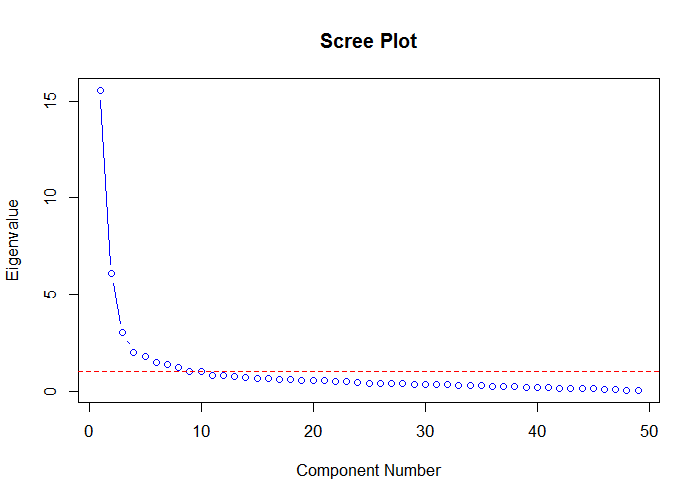

```r
# Diagnosing number of factors
Scree.Plot(R0)
```

```r
#The first 15 eigen values
data.frame(
  eigen = c(1:nrow(R0)),
  value = eigen(R0)$values
) %>%
  dplyr::filter(eigen < 16) %>%
  print()
```

```
   eigen      value
1      1 15.5464443
2      2  6.0701008
3      3  3.0215047
4      4  2.0079960
5      5  1.7679392
6      6  1.4593287
7      7  1.3778156
8      8  1.2151014
9      9  1.0094502
10    10  0.9982523
11    11  0.8091173
12    12  0.7928341
13    13  0.7500816
14    14  0.7169123
15    15  0.6768888
```

Scree plot is somewhat ambiguious, suggesting a solution involving 4-5 factors, while Keiser rule (eigenvalue > 1) suggests up to 9 factors.

## MAP

`psych::nfactors` call is applied, producing Very Simple Structure, Velicer’s MAP, and other criteria to determine the appropriate number of factors. See [documentation](http://www.personality-project.org/r/html/VSS.html)

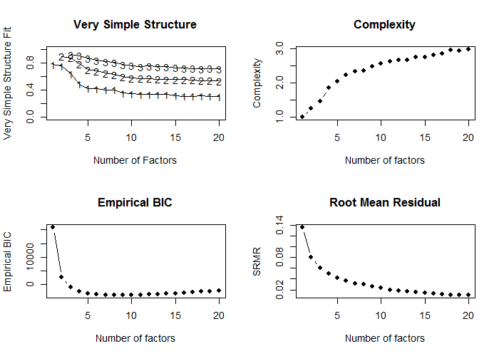

```
Number of factors
Call: vss(x = x, n = n, rotate = rotate, diagonal = diagonal, fm = fm,
    n.obs = n.obs, plot = FALSE, title = title, use = use, cor = cor)
VSS complexity 1 achieves a maximimum of 0.78  with  1  factors
VSS complexity 2 achieves a maximimum of 0.89  with  2  factors
The Velicer MAP achieves a minimum of 0.01  with  9  factors
Empirical BIC achieves a minimum of  -3999.01  with  7  factors
Sample Size adjusted BIC achieves a minimum of  -791.46  with  16  factors

Statistics by number of factors
   vss1 vss2   map  dof chisq     prob sqresid  fit RMSEA   BIC SABIC complex eChisq   SRMR eCRMS  eBIC
1  0.78 0.00 0.037 1127 14390  0.0e+00    69.3 0.78 0.137  7103 10681     1.0  28254 0.1367 0.140 20966
2  0.75 0.89 0.023 1079 10796  0.0e+00    32.5 0.89 0.120  3819  7245     1.3   9667 0.0799 0.083  2690
3  0.64 0.87 0.018 1032  8000  0.0e+00    23.9 0.92 0.104  1327  4604     1.5   5587 0.0608 0.065 -1086
4  0.49 0.78 0.015  986  5813  0.0e+00    19.7 0.94 0.089  -562  2568     1.9   3720 0.0496 0.054 -2656
5  0.42 0.70 0.014  941  4970  0.0e+00    16.6 0.95 0.083 -1114  1873     2.0   2671 0.0420 0.047 -3413
6  0.42 0.68 0.013  897  4362  0.0e+00    14.5 0.95 0.079 -1438  1410     2.2   2061 0.0369 0.042 -3739
7  0.40 0.65 0.013  854  3754  0.0e+00    12.7 0.96 0.074 -1768   943     2.3   1523 0.0317 0.037 -3999
8  0.40 0.63 0.013  812  2935 2.5e-237    12.3 0.96 0.065 -2315   263     2.4   1405 0.0305 0.037 -3846
9  0.36 0.60 0.012  771  2571 4.6e-192    10.7 0.97 0.062 -2414    34     2.5    999 0.0257 0.032 -3986
10 0.34 0.58 0.012  731  2228 6.5e-151     9.9 0.97 0.058 -2499  -178     2.6    810 0.0231 0.029 -3916
11 0.34 0.57 0.013  692  1898 6.9e-113     8.9 0.97 0.054 -2577  -380     2.6    585 0.0197 0.026 -3890
12 0.33 0.57 0.014  654  1681  1.8e-91     8.4 0.97 0.051 -2548  -472     2.7    483 0.0179 0.024 -3746
13 0.34 0.56 0.014  617  1325  9.8e-54     8.0 0.97 0.044 -2665  -706     2.7    407 0.0164 0.023 -3583
14 0.33 0.56 0.015  581  1181  3.8e-43     7.5 0.98 0.042 -2576  -731     2.7    334 0.0149 0.021 -3422
15 0.32 0.55 0.016  546  1015  1.4e-30     7.0 0.98 0.038 -2516  -782     2.8    276 0.0135 0.020 -3254
16 0.31 0.55 0.017  512   894  3.7e-23     6.7 0.98 0.036 -2417  -791     2.8    234 0.0124 0.019 -3077
17 0.31 0.55 0.018  479   795  4.8e-18     6.5 0.98 0.034 -2303  -782     2.9    213 0.0119 0.019 -2885
18 0.31 0.54 0.019  447   702  1.3e-13     6.2 0.98 0.032 -2188  -769     3.0    175 0.0108 0.017 -2715
19 0.31 0.54 0.021  416   608  2.2e-09     5.9 0.98 0.029 -2082  -761     3.0    159 0.0102 0.017 -2531
20 0.30 0.53 0.022  386   550  7.4e-08     5.7 0.98 0.028 -1946  -720     3.0    139 0.0096 0.017 -2357
```

```r
# MAP
psych::nfactors(R0,n.obs = 643)
```

## Parallel

`psych::fa.parallel` call is applied, comparing the number of factors in the correlation matrix to random “parallel” matrices. For details, see [documentation](https://www.rdocumentation.org/packages/psych/versions/1.6.9/topics/fa.parallel?)

```r
pa_results <- psych::fa.parallel(R0,643,fm = "ml",fa="fa")
```

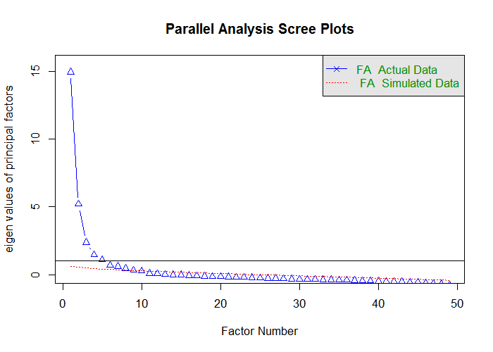

```
Parallel analysis suggests that the number of factors =  9  and the number of components =  NA
```

```r
ds_pa <- data.frame(
  observed_eigens = pa_results$fa.values,
  simulated_eigens = pa_results$fa.sim
) %>% head(15) %>% print()
```

```
   observed_eigens simulated_eigens
1      14.94487089        0.6129127
2       5.21708368        0.5302862
3       2.37587802        0.4828959
4       1.45560672        0.4476364
5       1.09227743        0.4194849
6       0.69844153        0.3851757
7       0.61012843        0.3596335
8       0.45511336        0.3304371
9       0.32340554        0.2985747
10      0.27259629        0.2782284
11      0.08722195        0.2521369
12      0.06374368        0.2322404
13      0.01338476        0.2165549
14     -0.01480093        0.1969096
15     -0.01810249        0.1728602
```

## Fit

`psych::fa` call is applied to conduct maximum likelihood factor analysls (`fm="ml"`) in order to obtain the chi-square of the proposed models, which incrementally increase the number of retained factors. CFI and TLI indices are then computed from the produced criteria. For details on `psych::fa` see [documentation](https://www.rdocumentation.org/packages/psych/versions/1.6.9/topics/fa)

```r
ls_solution <- solve_factors(R0,min=1,max=15,sample_size = 643)
ds_index <- get_indices(ls_solution)
```

## RMSEA

RMSEA diagnostic is conducted using [Advanced Factor Function](http://statpower.net/Content/312/R%20Stuff/AdvancedFactorFunctions.txt) by James Steiger. The routine relies on the maxim likelihood factor analysis conducted by `stats::factanal` call. For details on the latter see [here](https://stat.ethz.ch/R-manual/R-devel/library/stats/html/factanal.html)

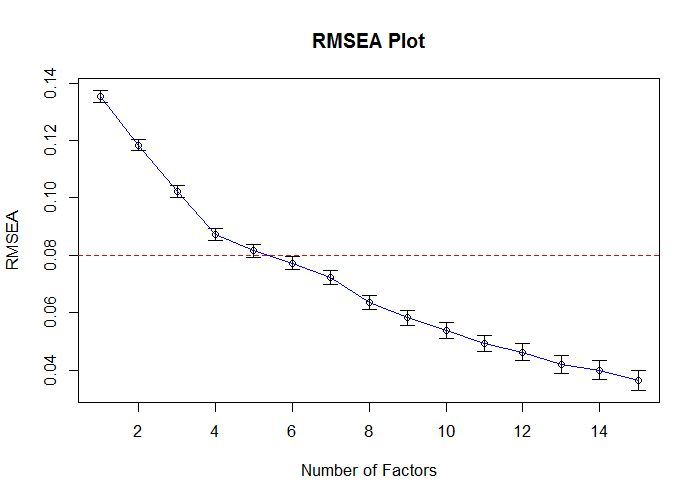

```
      Factors Cum.Eigen Chi-Square   Df p.value   RMSEA.Pt   RMSEA.Lo   RMSEA.Hi
 [1,]       1  15.54644  14390.417 1127       0 0.13539363 0.13342391 0.13737263
 [2,]       2  21.61655  10789.396 1079       0 0.11839687 0.11637184 0.12043263
 [3,]       3  24.63805   7965.640 1032       0 0.10229945 0.10021106 0.10440020
 [4,]       4  26.64605   5796.907  986       0 0.08717812 0.08501450 0.08935580
 [5,]       5  28.41399   4959.072  941       0 0.08155423 0.07932515 0.08379840
 [6,]       6  29.87331   4332.693  897       0 0.07724020 0.07494366 0.07955277
 [7,]       7  31.25113   3712.555  854       0 0.07220659 0.06983360 0.07459650
 [8,]       8  32.46623   2923.307  812       0 0.06364000 0.06116116 0.06613606
 [9,]       9  33.47568   2448.905  771       0 0.05822225 0.05563812 0.06082320
[10,]      10  34.47393   2092.926  731       0 0.05387044 0.05117417 0.05658229
[11,]      11  35.28305   1766.844  692       0 0.04918721 0.04635593 0.05203071
[12,]      12  36.07588   1549.766  654       0 0.04618925 0.04322740 0.04915953
[13,]      13  36.82597   1318.401  617       0 0.04207975 0.03894254 0.04521586
[14,]      14  37.54288   1176.173  581       0 0.03994533 0.03665421 0.04322725
[15,]      15  38.21977   1014.674  546       0 0.03656552 0.03305376 0.04004819
```

```r
FA.Stats(Correlation.Matrix = R0,n.obs = 643,n.factors = 1:15,RMSEA.cutoff = .08)
```

## Estimate

Using [Advanced Factor Function](http://statpower.net/Content/312/R%20Stuff/AdvancedFactorFunctions.txt) by James Steiger, we conduct maximum likelihood factor analysis, by obtaining the unrotated solution from `stats::factanal` call and then rotating solution using gradient projection algorithms (Bernaards & Jennrich, 2005).

```r
fit_efa_0 <- MLFA(
  Correlation.Matrix = R0,
  n.factors = 6,
  n.obs = 643,
  sort = FALSE
)
```

```
This will take a moment..........exiting
```

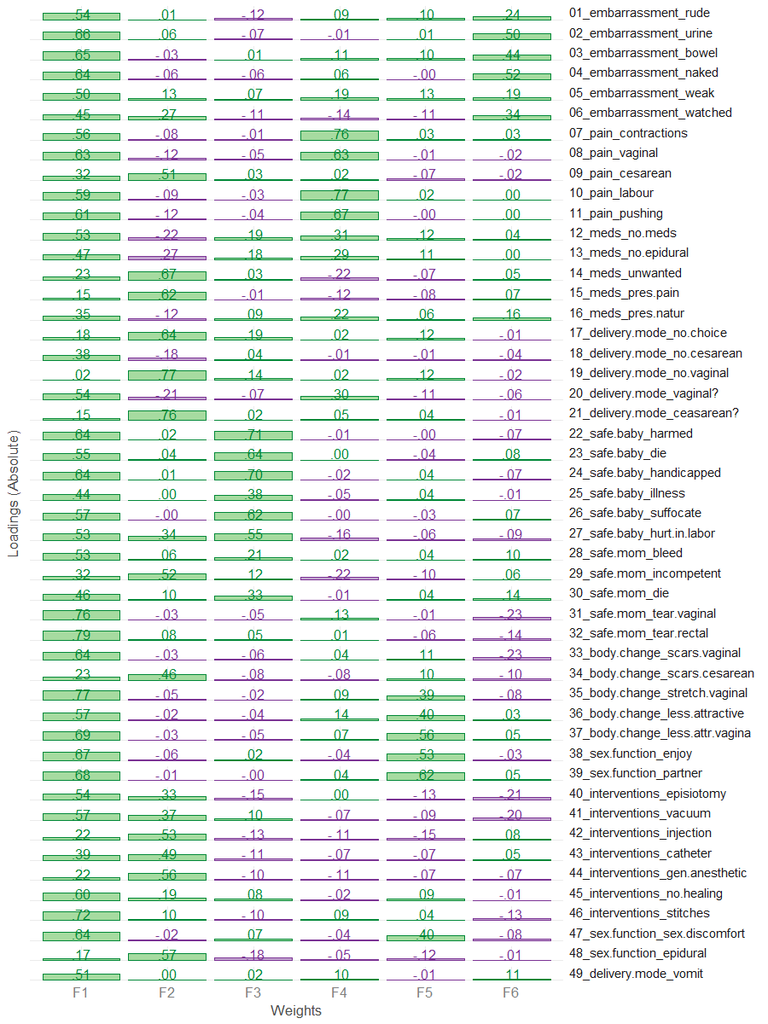

```r
#Loadings from the EFA solution\n")
f_pattern <- fit_efa_0[['Bifactor']]$F
f_pattern %>% plot_factor_pattern(factor_width = 6)
```

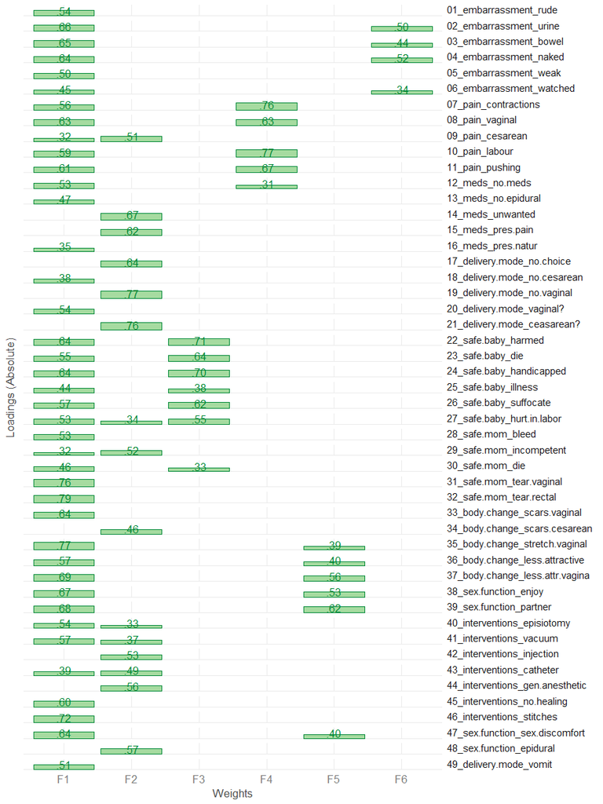

```r
# Loadings above threashold (.3) are masked to see the simpler structure
f_pattern[f_pattern<.30] <- NA
f_pattern %>% plot_factor_pattern(factor_width = 6)
```

## Confirm

Applying “Exploratory-Confirmatory” procedure described by [Joreskog(1978)](https://scholar.google.ca/scholar?q=Structural+analysis+of+covariance+and+correlation+matrices&btnG=&hl=en&as_sdt=0%2C33), we find the largest loading for each column of the factor pattern, then constrain all the other loadings in that row to be zero, and fit the resulting model as a confirmatory factor model. Given that we chose the orthogonal bifactor solution, we permit the the cross-loadings between general factor and subfactors.

```r
# These values are translated into CFA model and used as starting values
model_0 <- FAtoSEM(
  x                 = fit_efa_0[["Bifactor"]] ,
  cutoff            = 0.30,
  factor.names      = c("General","Interventions","Safety","Pain","Sex & Body","Shame"),
  make.start.values = TRUE,
  cov.matrix        = FALSE, # TRUE - oblique, FALSE - orthogonal
  num.digits        = 4
)
```

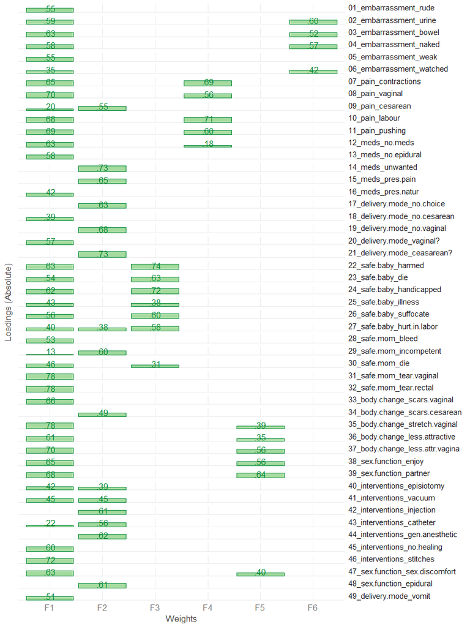

```r
# the model is estimated using sem package
fit_0 <- sem::sem(model_0,R0,sample_size)
# the pattern of the solution
m <- GetPattern(fit_0)$F
m[m==0] <- NA
m %>% plot_factor_pattern(factor_width=6)
```

```r
# Summary of the fitted model
sem_model_summary(fit_0)
```

```
Model Chiquare =  6071.013  | df model =  1099  | df null =  1176
Goodness-of-fit index =  0.7018118
Adjusted Goodness-of-fit index =  0.6676246
RMSEA index =  .0839           90% CI: (.082,.086)
Comparitive Fit Index (CFI = 0.7923754
Tucker Lewis Index (TLI/NNFI) =  0.7778285
Akaike Information Criterion (AIC) = 6323.013
Bayesian Information Criterion (BIC) = -1035.281
```

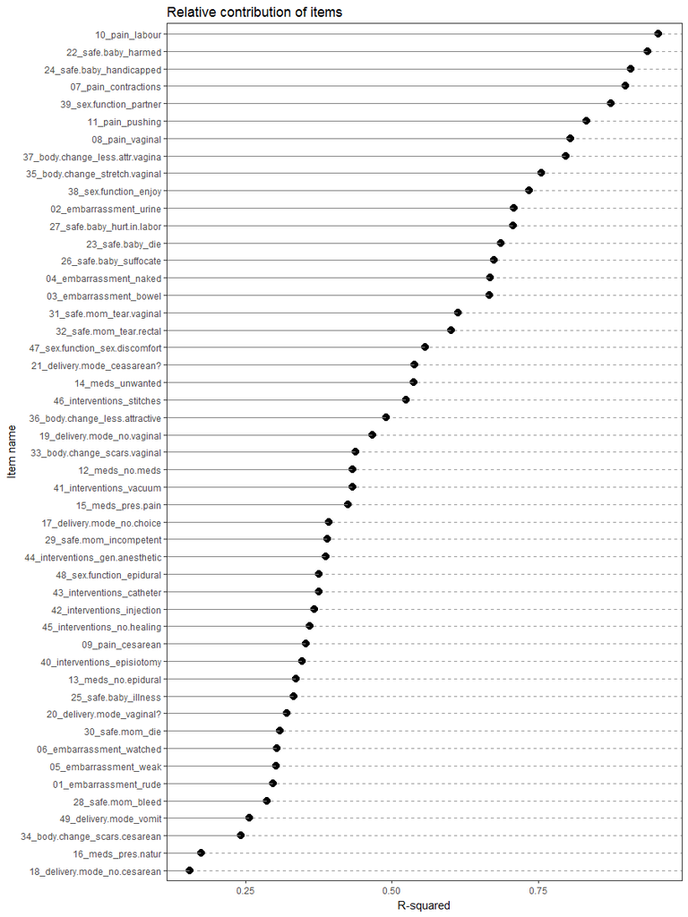

```r
#Relative contribudion of items
sort(summary(fit_0)$Rsq) %>% dot_plot()
```

# Phase 1

Based on the results from phase 0 we identified that `items 18` and `item 16` are performing poorly in the scale, based on the consideration we have outlined. They both do not have a non-trivial loading on any subscales (1), have small loadings on the general factor (2) and contribute marketly less to the R-square compared to other items (5). We also did not percieve them to be crucial for interpretive validity of the solution (4).

Thus we remove `item 16` and `item 18` from the pool of items and repeat the analytical steps.

```r
drop_items_1 <- c("foc_18","foc_16")
items_phase_1 <- setdiff(items_phase_0, drop_items_1)
R1 <- make_cor(ds, metaData, items_phase_1)
```

## Scree

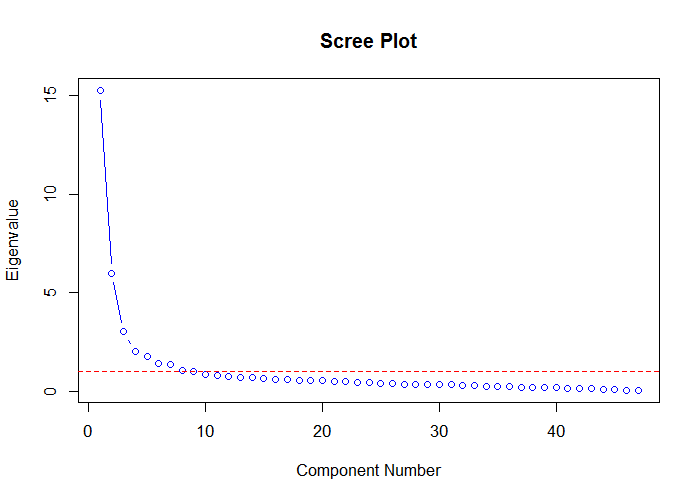

```r
# Diagnosing number of factors
Scree.Plot(R1)
```

```r
#The first 15 eigen values
data.frame(
  eigen = c(1:nrow(R1)),
  value = eigen(R1)$values
) %>%
  dplyr::filter(eigen < 16) %>%
  print()
```

```
   eigen      value
1      1 15.2610009
2      2  5.9755365
3      3  3.0168417
4      4  1.9983595
5      5  1.7537678
6      6  1.3995805
7      7  1.3757185
8      8  1.0354289
9      9  0.9894350
10    10  0.8274985
11    11  0.8074161
12    12  0.7185295
13    13  0.6993490
14    14  0.6689659
15    15  0.6543354
```

## MAP

`psych::nfactors` call is applied, producing Very Simple Structure, Velicer’s MAP, and other criteria to determine the appropriate number of factors. See [documentation](http://www.personality-project.org/r/html/VSS.html)

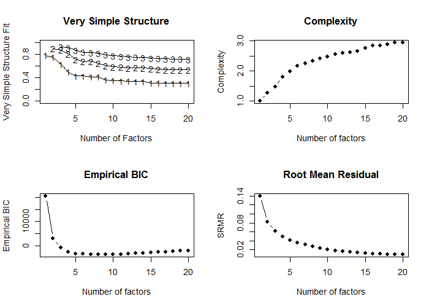

```
Number of factors
Call: vss(x = x, n = n, rotate = rotate, diagonal = diagonal, fm = fm,
    n.obs = n.obs, plot = FALSE, title = title, use = use, cor = cor)
VSS complexity 1 achieves a maximimum of 0.78  with  1  factors
VSS complexity 2 achieves a maximimum of 0.9  with  2  factors
The Velicer MAP achieves a minimum of 0.01  with  8  factors
Empirical BIC achieves a minimum of  -3717.33  with  9  factors
Sample Size adjusted BIC achieves a minimum of  -737.44  with  15  factors

Statistics by number of factors
   vss1 vss2   map  dof chisq     prob sqresid  fit RMSEA   BIC SABIC complex eChisq   SRMR eCRMS  eBIC
1  0.78 0.00 0.039 1034 13986  0.0e+00    66.3 0.78 0.142  7300 10583     1.0  27314 0.1402 0.143 20628
2  0.75 0.90 0.025  988 10420  0.0e+00    30.8 0.90 0.124  4032  7169     1.3   9377 0.0821 0.086  2988
3  0.63 0.87 0.020  943  7620  0.0e+00    22.0 0.93 0.107  1522  4516     1.5   5243 0.0614 0.066  -854
4  0.50 0.80 0.015  899  5435  0.0e+00    17.7 0.94 0.090  -378  2476     1.8   3328 0.0489 0.054 -2485
5  0.43 0.71 0.014  856  4618  0.0e+00    14.6 0.95 0.084  -917  1801     2.0   2291 0.0406 0.046 -3244
6  0.43 0.67 0.013  814  4024  0.0e+00    13.1 0.96 0.080 -1240  1345     2.2   1819 0.0362 0.042 -3444
7  0.41 0.68 0.013  773  3430  0.0e+00    11.7 0.96 0.075 -1568   886     2.2   1438 0.0322 0.038 -3560
8  0.41 0.64 0.012  733  2748 4.2e-230    10.3 0.97 0.067 -1991   336     2.3   1062 0.0276 0.034 -3678
9  0.36 0.61 0.012  694  2267 6.7e-166     9.2 0.97 0.061 -2221   -17     2.4    770 0.0235 0.029 -3717
10 0.35 0.58 0.013  656  1919 4.7e-124     8.5 0.97 0.056 -2323  -240     2.5    590 0.0206 0.026 -3652
11 0.35 0.58 0.013  619  1623  4.3e-91     7.9 0.97 0.052 -2379  -414     2.5    458 0.0182 0.024 -3544
12 0.34 0.57 0.014  583  1288  3.1e-55     7.5 0.97 0.045 -2481  -630     2.6    389 0.0167 0.023 -3381
13 0.33 0.57 0.015  548  1138  1.5e-43     7.1 0.98 0.043 -2405  -665     2.6    331 0.0154 0.022 -3212
14 0.33 0.57 0.016  514   988  2.7e-32     6.7 0.98 0.040 -2336  -704     2.7    275 0.0141 0.020 -3048
15 0.31 0.56 0.017  481   846  1.9e-22     6.2 0.98 0.036 -2265  -737     2.8    205 0.0122 0.018 -2905
16 0.31 0.54 0.018  449   748  2.7e-17     6.0 0.98 0.034 -2155  -730     2.8    182 0.0114 0.018 -2721
17 0.31 0.53 0.019  418   639  1.6e-11     5.8 0.98 0.031 -2064  -736     2.8    163 0.0108 0.017 -2540
18 0.30 0.53 0.021  388   562  1.6e-08     5.6 0.98 0.028 -1947  -715     2.9    135 0.0099 0.016 -2374
19 0.31 0.53 0.022  359   495  2.4e-06     5.3 0.98 0.026 -1826  -686     2.9    113 0.0090 0.016 -2208
20 0.30 0.53 0.025  331   496  1.0e-08     5.4 0.98 0.030 -1644  -593     2.9    113 0.0090 0.016 -2027
```

```r
# MAP
psych::nfactors(R1,n.obs = 643)
```

## Parallel

`psych::fa.parallel` call is applied, comparing the number of factors in the correlation matrix to random “parallel” matrices. For details, see [documentation](https://www.rdocumentation.org/packages/psych/versions/1.6.9/topics/fa.parallel?)

```r
pa_results <- psych::fa.parallel(R1,643,fm = "ml",fa="fa")
```

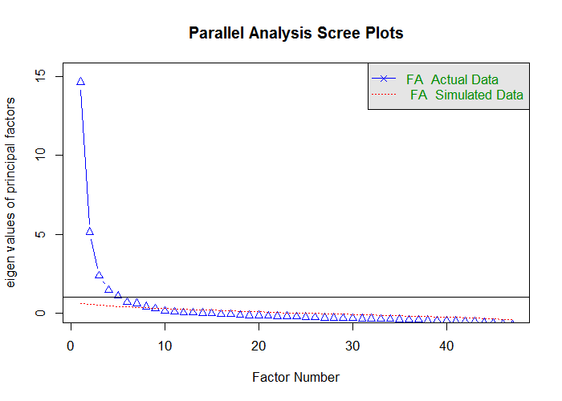

```
Parallel analysis suggests that the number of factors =  8  and the number of components =  NA
```

```r
ds_pa <- data.frame(
  observed_eigens = pa_results$fa.values,
  simulated_eigens = pa_results$fa.sim
) %>% head(15) %>% print()
```

```
   observed_eigens simulated_eigens
1     14.662802646        0.6043505
2      5.128267536        0.5193953
3      2.370174574        0.4702202
4      1.445452900        0.4347149
5      1.077566306        0.3986833
6      0.657691710        0.3687463
7      0.598542772        0.3443344
8      0.387275698        0.3212421
9      0.264490654        0.2943009
10     0.117594262        0.2662103
11     0.062287508        0.2438114
12     0.015919955        0.2247295
13     0.004584041        0.2019165
14    -0.022108291        0.1825661
15    -0.037872320        0.1619618
```

## Fit

`psych::fa` call is applied to conduct maximum likelihood factor analysls (`fm="ml"`) in order to obtain the chi-square of the proposed models, which incrementally increase the number of retained factors. CFI and TLI indices are then computed from the produced criteria. For details on `psych::fa` see [documentation](https://www.rdocumentation.org/packages/psych/versions/1.6.9/topics/fa)

```r
ls_solution <- solve_factors(R1,min=1,max=15,sample_size = 643)
ds_index <- get_indices(ls_solution)
ds_index
```

```
   n_factors chisq_null df_null      chisq   df        CFI        TLI
1          1   23866.17    1081 27313.5521 1034 -0.1533621 -0.2057876
2          2   23866.17    1081  9376.9482  988  0.6318242  0.5971680
3          3   23866.17    1081  5243.4121  943  0.8112627  0.7836426
4          4   23866.17    1081  3328.4142  899  0.8933774  0.8717920
5          5   23866.17    1081  2290.9707  856  0.9370217  0.9204679
6          6   23866.17    1081  1818.9932  814  0.9558927  0.9414250
7          7   23866.17    1081  1438.2916  773  0.9708016  0.9591675
8          8   23866.17    1081  1061.5430  733  0.9855808  0.9787352
9          9   23866.17    1081   770.1728  694  0.9966569  0.9947927
10        10   23866.17    1081   589.6575  656  1.0029117  1.0047980
11        11   23866.17    1081   458.1732  619  1.0070584  1.0123265
12        12   23866.17    1081   388.5802  583  1.0085327  1.0158214
13        13   23866.17    1081   331.4643  548  1.0095034  1.0187466
14        14   23866.17    1081   275.1349  514  1.0104834  1.0220477
15        15   23866.17    1081   205.2746  481  1.0121011  1.0271960
```

## RMSEA

RMSEA diagnostic is conducted using [Advanced Factor Function](http://statpower.net/Content/312/R%20Stuff/AdvancedFactorFunctions.txt) by James Steiger. The routine relies on the maxim likelihood factor analysis conducted by `stats::factanal` call. For details on the latter see [here](https://stat.ethz.ch/R-manual/R-devel/library/stats/html/factanal.html)

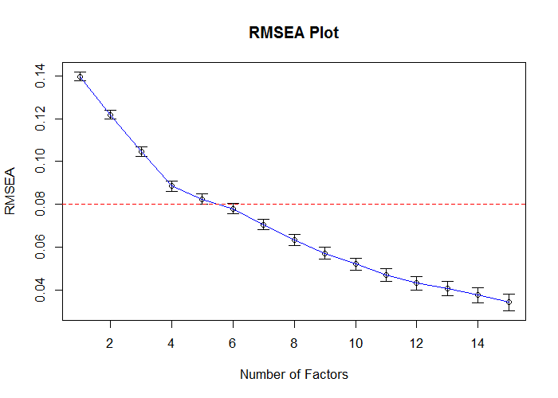

```
      Factors Cum.Eigen Chi-Square   Df p.value   RMSEA.Pt   RMSEA.Lo   RMSEA.Hi
 [1,]       1  15.26100 13986.3420 1034       0 0.13968391 0.13763014 0.14174752
 [2,]       2  21.23654 10402.0125  988       0 0.12182640 0.11971339 0.12395087
 [3,]       3  24.25338  7582.5146  943       0 0.10472366 0.10254262 0.10691803
 [4,]       4  26.25174  5415.9730  899       0 0.08846600 0.08620346 0.09074386
 [5,]       5  28.00551  4590.7989  856       0 0.08243834 0.08010419 0.08478901
 [6,]       6  29.40509  3985.3098  814       0 0.07790039 0.07549237 0.08032603
 [7,]       7  30.78081  3246.6647  773       0 0.07060137 0.06810014 0.07312128
 [8,]       8  31.81623  2623.4219  733       0 0.06338111 0.06077085 0.06601042
 [9,]       9  32.80567  2149.5036  694       0 0.05715568 0.05442262 0.05990698
[10,]      10  33.63317  1796.4776  656       0 0.05203840 0.04917031 0.05492240
[11,]      11  34.44058  1497.2259  619       0 0.04701000 0.04398061 0.05004978
[12,]      12  35.15911  1281.7351  583       0 0.04320704 0.04000694 0.04640942
[13,]      13  35.85846  1127.4416  548       0 0.04058327 0.03721317 0.04394638
[14,]      14  36.52743   980.3371  514       0 0.03759247 0.03401236 0.04114885
[15,]      15  37.18176   843.5561  481       0 0.03426475 0.03041564 0.03805916
```

```r
FA.Stats(Correlation.Matrix = R1,n.obs = 643,n.factors = 1:15,RMSEA.cutoff = .08)
```

## Estimate

Using [Advanced Factor Function](http://statpower.net/Content/312/R%20Stuff/AdvancedFactorFunctions.txt) by James Steiger, we conduct maximum likelihood factor analysis, by obtaining the unrotated solution from `stats::factanal` call and then rotating solution using gradient projection algorithms (Bernaards & Jennrich, 2005).

```r
fit_efa_1 <- MLFA(
  Correlation.Matrix = R1,
  n.factors = 6,
  n.obs = 643,
  sort = FALSE
)
```

```
This will take a moment..........exiting
```

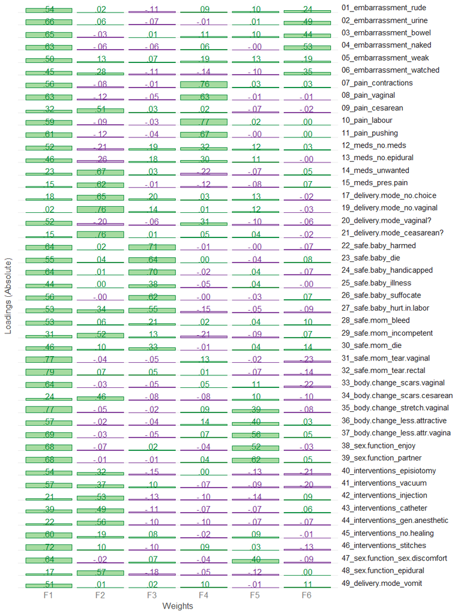

```r
#Loadings from the EFA solution\n")
f_pattern <- fit_efa_1[['Bifactor']]$F
f_pattern %>% plot_factor_pattern(factor_width = 6)
```

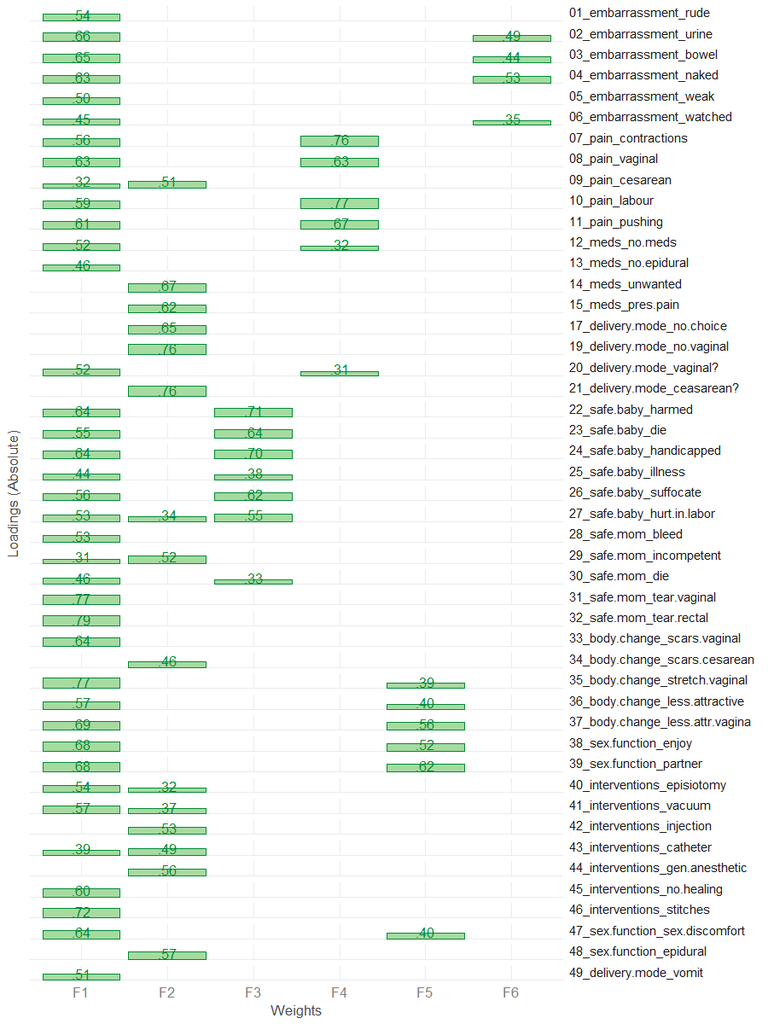

```r
# Loadings above threashold (.3) are masked to see the simpler structure
f_pattern[f_pattern<.30] <- NA
f_pattern %>% plot_factor_pattern(factor_width = 6)
```

## Confirm

Applying “Exploratory-Confirmatory” procedure described by [Joreskog(1978)](https://scholar.google.ca/scholar?q=Structural+analysis+of+covariance+and+correlation+matrices&btnG=&hl=en&as_sdt=0%2C33), we find the largest loading for each column of the factor pattern, then constrain all the other loadings in that row to be zero, and fit the resulting model as a confirmatory factor model. Given that we chose the orthogonal bifactor solution, we permit the the cross-loadings between general factor and subfactors.

```r
# These values are translated into CFA model and used as starting values
model_1 <- FAtoSEM(
  x                 = fit_efa_1[["Bifactor"]] ,
  cutoff            = 0.30,
  factor.names      = c("General","Interventions","Safety","Pain","Sex & Body","Shame"),
  make.start.values = TRUE,
  cov.matrix        = FALSE, # TRUE - oblique, FALSE - orthogonal
  num.digits        = 4
)
```

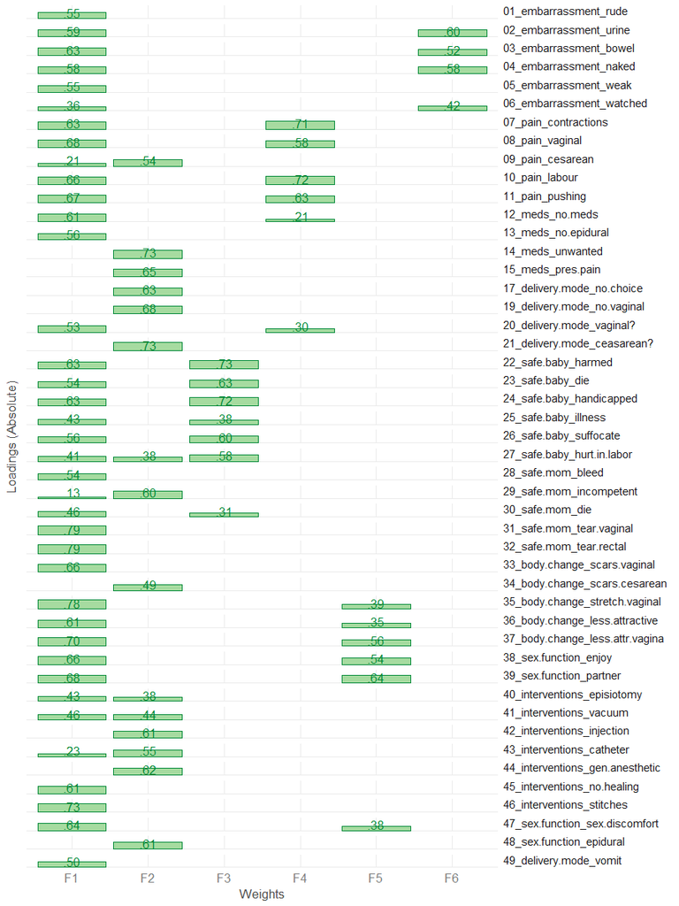

```r
# the model is estimated using sem package
fit_1 <- sem::sem(model_1,R1,sample_size)
# the pattern of the solution
m <- GetPattern(fit_1)$F
m[m==0] <- NA
m %>% plot_factor_pattern(factor_width=6)
```

```r
# Summary of the fitted model
sem_model_summary(fit_1)
```

```
Model Chiquare =  5579.292  | df model =  1005  | df null =  1081
Goodness-of-fit index =  0.7145923
Adjusted Goodness-of-fit index =  0.6796618
RMSEA index =  .0842           90% CI: (.082,.086)
Comparitive Fit Index (CFI = 0.8046405
Tucker Lewis Index (TLI/NNFI) =  0.789867
Akaike Information Criterion (AIC) = 5825.292
Bayesian Information Criterion (BIC) = -919.1839
```

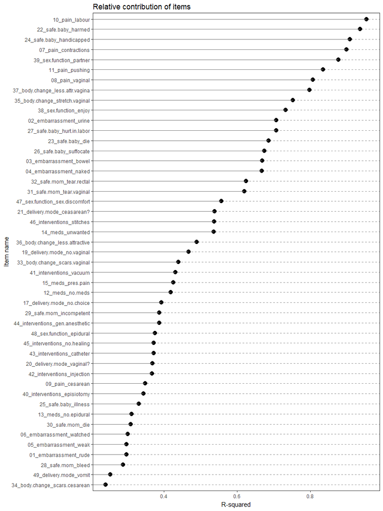

```r
#Relative contribudion of items
sort(summary(fit_1)$Rsq) %>% dot_plot()
```

# Phase 2

Based on the results from phase 1 we identified that `item 49` performs poorly on the scale, according to the consideration we have outlined. It does not load on any of the subscales (1) and has a borderline non-trivial loading on the general factor (2). Also, we didn’t think it was contributing coherence or interpretability to the scale (4). Although `item 34` had a lower R-square contribution than `item 49`, we did not remove it from the scale because it has a stong subscale loading and contributed to interpretability.

Thus we removed `item 49` from the pool of items and repeat the analytical steps.

```r
drop_items_2 <- c("foc_49")
items_phase_2 <- setdiff(items_phase_1, drop_items_2)
R2 <- make_cor(ds, metaData, items_phase_2)
```

## Scree

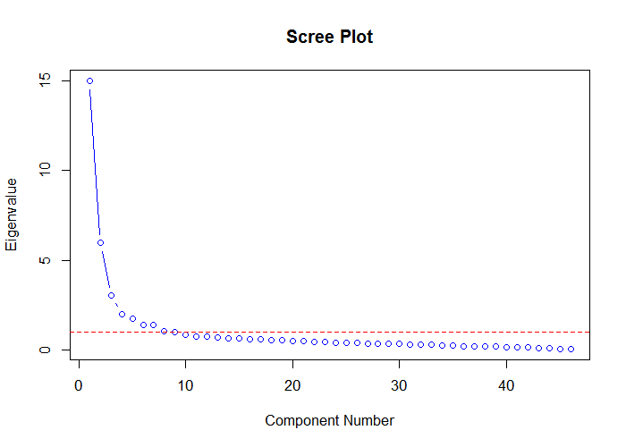

```r
# Diagnosing number of factors
Scree.Plot(R2)
```

```r
#The first 15 eigen values
data.frame(
  eigen = c(1:nrow(R2)),
  value = eigen(R2)$values
) %>%
  dplyr::filter(eigen < 16) %>%
  print()
```

```
   eigen      value
1      1 15.0033580
2      2  5.9706177
3      3  3.0128922
4      4  1.9974413
5      5  1.7318636
6      6  1.3978818
7      7  1.3694589
8      8  1.0354151
9      9  0.9731544
10    10  0.8227477
11    11  0.7544838
12    12  0.7076260
13    13  0.6771612
14    14  0.6551042
15    15  0.6087487
```

## MAP

`psych::nfactors` call is applied, producing Very Simple Structure, Velicer’s MAP, and other criteria to determine the appropriate number of factors. See [documentation](http://www.personality-project.org/r/html/VSS.html)

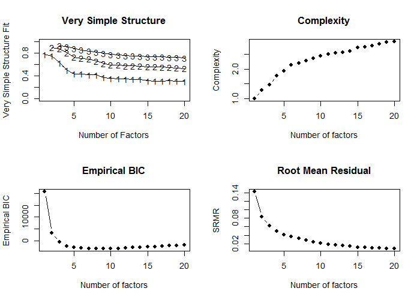

```
Number of factors
Call: vss(x = x, n = n, rotate = rotate, diagonal = diagonal, fm = fm,
    n.obs = n.obs, plot = FALSE, title = title, use = use, cor = cor)
VSS complexity 1 achieves a maximimum of 0.77  with  1  factors
VSS complexity 2 achieves a maximimum of 0.9  with  2  factors
The Velicer MAP achieves a minimum of 0.01  with  8  factors
Empirical BIC achieves a minimum of  -3512.42  with  9  factors
Sample Size adjusted BIC achieves a minimum of  -709.97  with  16  factors

Statistics by number of factors
   vss1 vss2   map dof chisq     prob sqresid  fit RMSEA   BIC SABIC complex eChisq   SRMR eCRMS  eBIC
1  0.77 0.00 0.041 989 13903  0.0e+00    65.6 0.77 0.145  7508 10648     1.0  27208 0.1430 0.146 20813
2  0.75 0.90 0.026 944 10337  0.0e+00    30.1 0.90 0.126  4233  7230     1.3   9291 0.0836 0.087  3187
3  0.63 0.87 0.020 900  7532  0.0e+00    21.4 0.93 0.109  1712  4570     1.5   5183 0.0624 0.067  -636
4  0.50 0.81 0.016 857  5345  0.0e+00    17.0 0.94 0.092  -196  2525     1.8   3245 0.0494 0.054 -2296
5  0.44 0.73 0.014 815  4543  0.0e+00    14.0 0.95 0.086  -727  1861     1.9   2247 0.0411 0.046 -3023
6  0.43 0.70 0.014 774  3969  0.0e+00    12.4 0.96 0.082 -1035  1422     2.1   1750 0.0363 0.042 -3255
7  0.42 0.70 0.014 734  3360  0.0e+00    11.2 0.96 0.076 -1386   945     2.2   1426 0.0327 0.039 -3320
8  0.42 0.66 0.013 695  2680 3.0e-230     9.8 0.97 0.068 -1814   393     2.3   1020 0.0277 0.034 -3474
9  0.37 0.62 0.013 657  2204 4.5e-166     8.7 0.97 0.062 -2044    42     2.4    736 0.0235 0.030 -3512
10 0.36 0.59 0.013 620  1859 6.7e-124     8.0 0.97 0.057 -2150  -181     2.4    562 0.0206 0.027 -3447
11 0.35 0.59 0.014 584  1564  1.6e-90     7.4 0.97 0.053 -2212  -358     2.5    432 0.0180 0.024 -3345
12 0.35 0.57 0.014 549  1230  3.4e-54     7.0 0.98 0.045 -2320  -577     2.5    365 0.0165 0.023 -3185
13 0.34 0.58 0.015 515  1082  1.8e-42     6.6 0.98 0.043 -2248  -613     2.5    307 0.0152 0.022 -3023
14 0.34 0.57 0.016 482   925  3.2e-30     6.1 0.98 0.039 -2192  -662     2.6    246 0.0136 0.020 -2871
15 0.31 0.56 0.017 450   784  1.7e-20     5.7 0.98 0.036 -2125  -697     2.7    180 0.0116 0.018 -2730
16 0.31 0.56 0.018 419   669  8.7e-14     5.4 0.98 0.032 -2040  -710     2.7    155 0.0108 0.017 -2554
17 0.31 0.56 0.020 389   582  8.0e-10     5.3 0.98 0.030 -1934  -699     2.8    136 0.0101 0.017 -2379
18 0.31 0.55 0.021 360   500  1.4e-06     5.0 0.98 0.027 -1828  -685     2.8    110 0.0091 0.015 -2218
19 0.31 0.54 0.024 332   440  6.5e-05     4.8 0.98 0.025 -1707  -653     2.9     93 0.0084 0.015 -2054
20 0.30 0.53 0.026 305   369  7.1e-03     4.6 0.98 0.020 -1603  -635     2.9     81 0.0078 0.014 -1891
```

```r
# MAP
psych::nfactors(R2,n.obs = 643)
```

## Parallel

`psych::fa.parallel` call is applied, comparing the number of factors in the correlation matrix to random “parallel” matrices. For details, see [documentation](https://www.rdocumentation.org/packages/psych/versions/1.6.9/topics/fa.parallel?)

```r
pa_results <- psych::fa.parallel(R2,643,fm = "ml",fa="fa")
```

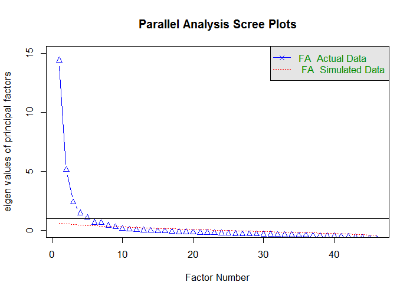

```
Parallel analysis suggests that the number of factors =  8  and the number of components =  NA
```

```r
ds_pa <- data.frame(
  observed_eigens = pa_results$fa.values,
  simulated_eigens = pa_results$fa.sim
) %>% head(15) %>% print()
```

```
   observed_eigens simulated_eigens
1     14.407375452        0.5880388
2      5.124208493        0.5099805
3      2.366897162        0.4680602
4      1.443153319        0.4394414
5      1.059351774        0.3907020
6      0.644409830        0.3669435
7      0.597139091        0.3364833
8      0.387436292        0.3050397
9      0.247329236        0.2814304
10     0.112050211        0.2578445
11     0.057576688        0.2388899
12     0.006134471        0.2153173
13    -0.020916243        0.1895567
14    -0.031829792        0.1732683
15    -0.084688321        0.1530912
```

## Fit

`psych::fa` call is applied to conduct maximum likelihood factor analysls (`fm="ml"`) in order to obtain the chi-square of the proposed models, which incrementally increase the number of retained factors. CFI and TLI indices are then computed from the produced criteria. For details on `psych::fa` see [documentation](https://www.rdocumentation.org/packages/psych/versions/1.6.9/topics/fa)

```r
ls_solution <- solve_factors(R2,min=1,max=15,sample_size = 643)
ds_index <- get_indices(ls_solution)
ds_index %>% print()
```

```
   n_factors chisq_null df_null      chisq  df        CFI        TLI
1          1   23609.91    1035 27207.9185 989 -0.1614183 -0.2154378
2          2   23609.91    1035  9291.2546 944  0.6302420  0.5945980
3          3   23609.91    1035  5183.1288 900  0.8102704  0.7818110
4          4   23609.91    1035  3245.0735 857  0.8942156  0.8722441
5          5   23609.91    1035  2246.9747 815  0.9365679  0.9194451
6          6   23609.91    1035  1750.2273 774  0.9567561  0.9421739
7          7   23609.91    1035  1425.9096 734  0.9693505  0.9567817
8          8   23609.91    1035  1020.3561 695  0.9855877  0.9785371
9          9   23609.91    1035   735.8401 657  0.9965076  0.9944983
10        10   23609.91    1035   562.3911 620  1.0025519  1.0042600
11        11   23609.91    1035   431.6603 584  1.0067482  1.0119595
12        12   23609.91    1035   364.5061 549  1.0081725  1.0154072
13        13   23609.91    1035   306.6366 515  1.0092299  1.0185493
14        14   23609.91    1035   245.9683 482  1.0104555  1.0224511
15        15   23609.91    1035   180.0110 450  1.0119597  1.0275073
```

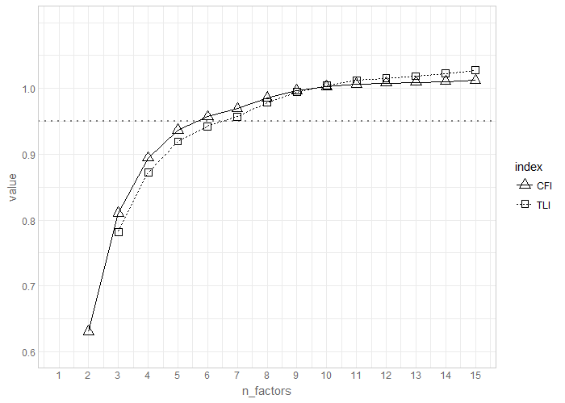

```r
ds_index %>% plot_fit_indices()
```

## RMSEA

RMSEA diagnostic is conducted using [Advanced Factor Function](http://statpower.net/Content/312/R%20Stuff/AdvancedFactorFunctions.txt) by James Steiger. The routine relies on the maxim likelihood factor analysis conducted by `stats::factanal` call. For details on the latter see [here](https://stat.ethz.ch/R-manual/R-devel/library/stats/html/factanal.html)

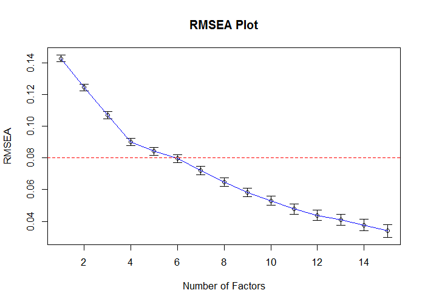

```
      Factors Cum.Eigen Chi-Square  Df p.value   RMSEA.Pt   RMSEA.Lo   RMSEA.Hi
 [1,]       1  15.00336 13903.0467 989       0 0.14261510 0.14051681 0.14472353
 [2,]       2  20.97398 10317.3180 944       0 0.12436357 0.12220411 0.12653485
 [3,]       3  23.98687  7493.2207 900       0 0.10682184 0.10459227 0.10906520
 [4,]       4  25.98431  5323.4596 857       0 0.09009979 0.08778639 0.09242913
 [5,]       5  27.71617  4516.7319 815       0 0.08411165 0.08172453 0.08651601
 [6,]       6  29.11405  3915.2005 774       0 0.07950782 0.07704420 0.08198989
 [7,]       7  30.48351  3175.5703 734       0 0.07198120 0.06942126 0.07456082
 [8,]       8  31.51893  2554.7581 695       0 0.06456071 0.06188834 0.06725337
 [9,]       9  32.49208  2087.0070 657       0 0.05822626 0.05542771 0.06104454
[10,]      10  33.31483  1736.7420 620       0 0.05296794 0.05002994 0.05592359
[11,]      11  34.06931  1437.7686 584       0 0.04771953 0.04461352 0.05083777
[12,]      12  34.77694  1223.7316 549       0 0.04375340 0.04046865 0.04704219
[13,]      13  35.45410  1068.0991 515       0 0.04090066 0.03743347 0.04436180
[14,]      14  36.10921   921.6697 482       0 0.03769400 0.03400031 0.04136305
[15,]      15  36.71795   784.2585 450       0 0.03401476 0.03002067 0.03794733
```

```r
FA.Stats(Correlation.Matrix = R2,n.obs = 643,n.factors = 1:15,RMSEA.cutoff = .08)
```

## Estimate

Using [Advanced Factor Function](http://statpower.net/Content/312/R%20Stuff/AdvancedFactorFunctions.txt) by James Steiger, we conduct maximum likelihood factor analysis, by obtaining the unrotated solution from `stats::factanal` call and then rotating solution using gradient projection algorithms (Bernaards & Jennrich, 2005).

```r
fit_efa_2 <- MLFA(
  Correlation.Matrix = R2,
  n.factors = 6,
  n.obs = 643,
  sort = FALSE
)
```

```
This will take a moment..........exiting
```

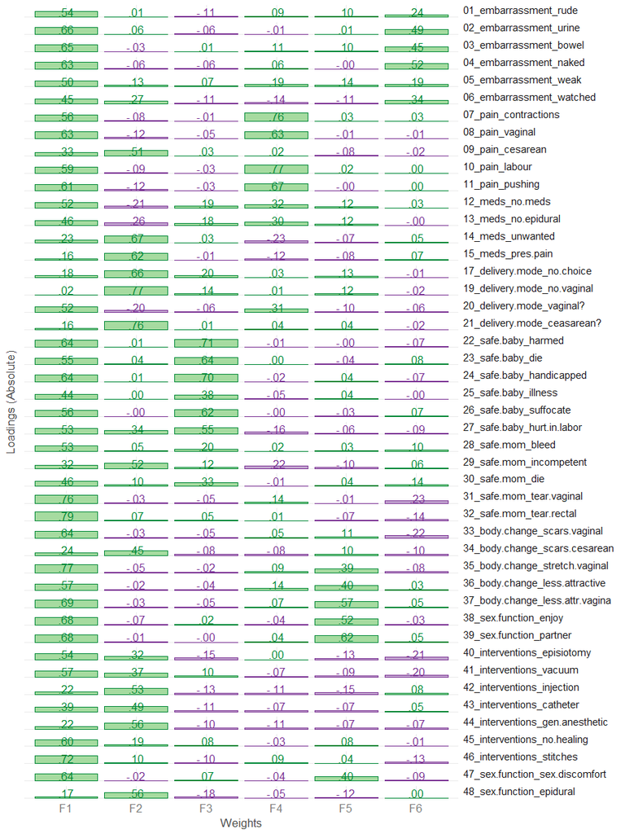

```r
#Loadings from the EFA solution\n")
f_pattern <- fit_efa_2[['Bifactor']]$F
f_pattern %>% plot_factor_pattern(factor_width = 6)
```

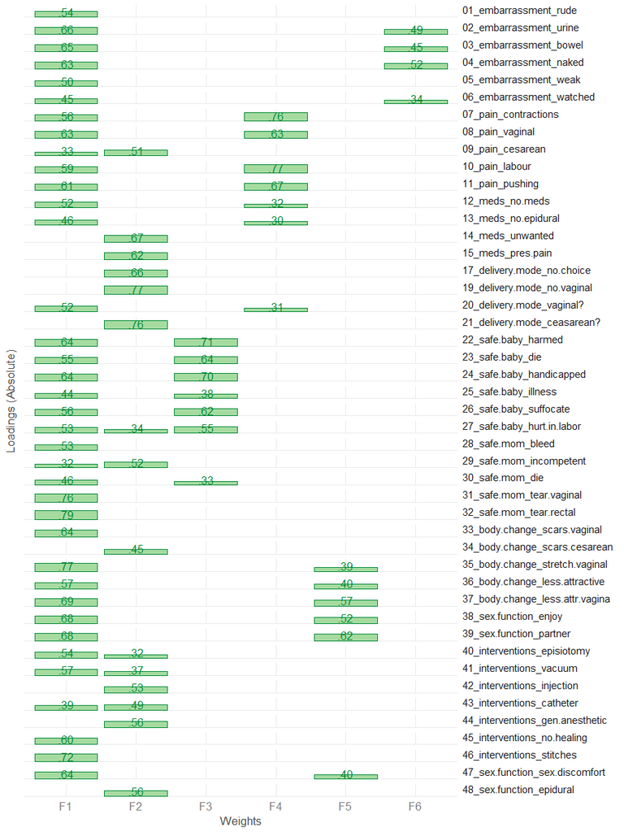

```r
# Loadings above threashold (.3) are masked to see the simpler structure
f_pattern[f_pattern<.30] <- NA
f_pattern %>% plot_factor_pattern(factor_width = 6)
```

## Confirm

Applying “Exploratory-Confirmatory” procedure described by [Joreskog(1978)](https://scholar.google.ca/scholar?q=Structural+analysis+of+covariance+and+correlation+matrices&btnG=&hl=en&as_sdt=0%2C33), we find the largest loading for each column of the factor pattern, then constrain all the other loadings in that row to be zero, and fit the resulting model as a confirmatory factor model. Given that we chose the orthogonal bifactor solution, we permit the the cross-loadings between general factor and subfactors.

```r
# These values are translated into CFA model and used as starting values
model_2 <- FAtoSEM(
  x                 = fit_efa_2[["Bifactor"]] ,
  cutoff            = 0.30,
  factor.names      = c("General","Interventions","Safety","Pain","Sex & Body","Shame"),
  make.start.values = TRUE,
  cov.matrix        = FALSE, # TRUE - oblique, FALSE - orthogonal
  num.digits        = 4
)
```

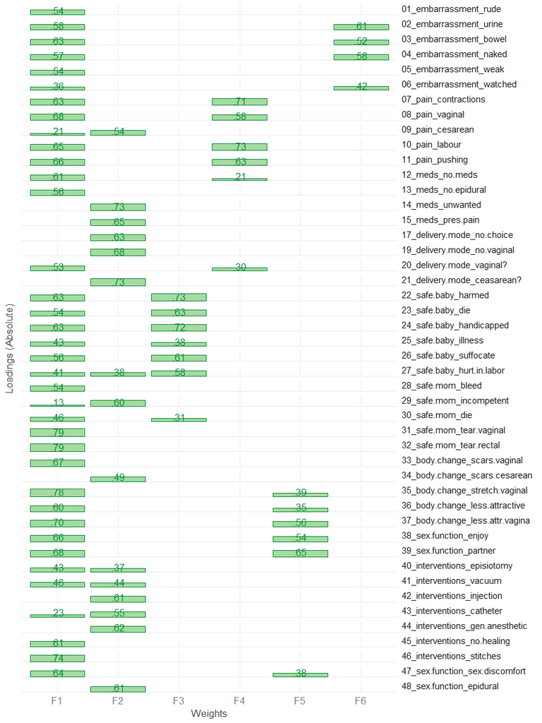

```r
# the model is estimated using sem package
fit_2 <- sem::sem(model_2,R2,sample_size)
# the pattern of the solution
m <- GetPattern(fit_2)$F
m[m==0] <- NA
m %>% plot_factor_pattern(factor_width=6)
```

```r
# Summary of the fitted model
sem_model_summary(fit_2)
```

```
Model Chiquare =  5476.325  | df model =  960  | df null =  1035
Goodness-of-fit index =  0.7139425
Adjusted Goodness-of-fit index =  0.6778874
RMSEA index =  .0856           90% CI: (.083,.088)
Comparitive Fit Index (CFI = 0.8052033
Tucker Lewis Index (TLI/NNFI) =  0.7899848
Akaike Information Criterion (AIC) = 5718.325
Bayesian Information Criterion (BIC) = -731.1739
```

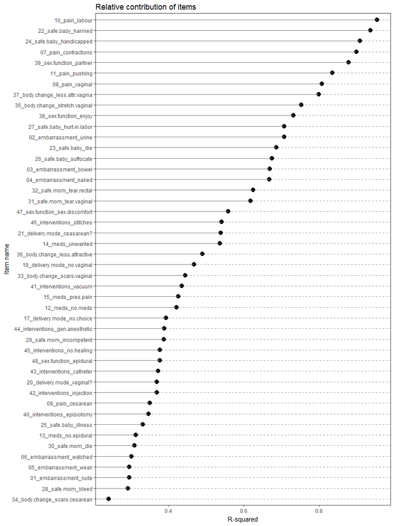

```r
#Relative contribudion of items
sort(summary(fit_2)$Rsq) %>% dot_plot()
```

# Phase 3

Thus we removed `item 27` from the pool of items and repeat the analytical steps.

```r
drop_items_3 <- c("foc_27")
items_phase_3 <- setdiff(items_phase_2, drop_items_3)
R3 <- make_cor(ds, metaData, items_phase_3)
```

## Scree

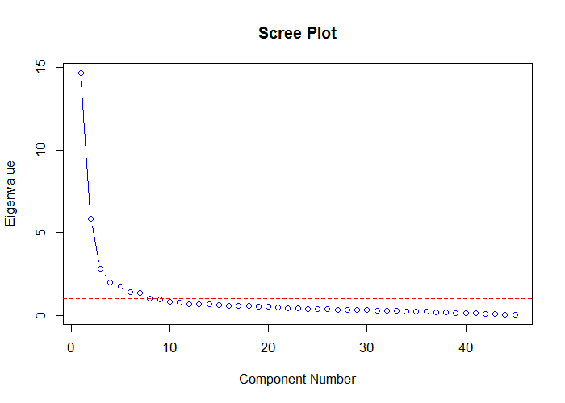

```r
# Diagnosing number of factors
Scree.Plot(R3)
```

```r
#The first 15 eigen values
data.frame(
  eigen = c(1:nrow(R3)),
  value = eigen(R3)$values
) %>%
  dplyr::filter(eigen < 16) %>%
  print()
```

```
   eigen      value
1      1 14.6487510
2      2  5.8489709
3      3  2.8037872
4      4  1.9872289
5      5  1.7314314
6      6  1.3964740
7      7  1.3571005
8      8  1.0309481
9      9  0.9631267
10    10  0.8068630
11    11  0.7538167
12    12  0.6892828
13    13  0.6724461
14    14  0.6547391
15    15  0.6036542
```

## MAP

`psych::nfactors` call is applied, producing Very Simple Structure, Velicer’s MAP, and other criteria to determine the appropriate number of factors. See [documentation](http://www.personality-project.org/r/html/VSS.html)

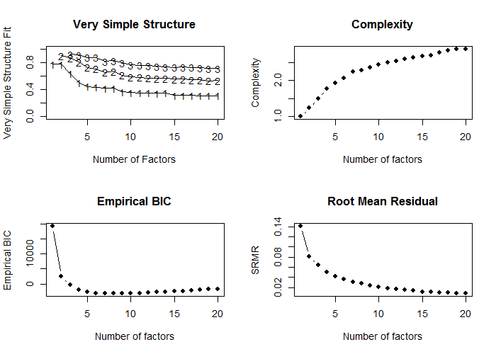

```
Number of factors
Call: vss(x = x, n = n, rotate = rotate, diagonal = diagonal, fm = fm,
    n.obs = n.obs, plot = FALSE, title = title, use = use, cor = cor)
VSS complexity 1 achieves a maximimum of 0.77  with  2  factors
VSS complexity 2 achieves a maximimum of 0.9  with  2  factors
The Velicer MAP achieves a minimum of 0.01  with  8  factors
Empirical BIC achieves a minimum of  -3302.52  with  9  factors
Sample Size adjusted BIC achieves a minimum of  -684.33  with  15  factors

Statistics by number of factors
   vss1 vss2   map dof chisq     prob sqresid  fit RMSEA   BIC
1  0.77 0.00 0.039 945 13224  0.0e+00    62.7 0.77 0.144  7113
2  0.77 0.90 0.025 901  9852  0.0e+00    28.2 0.90 0.126  4026
3  0.63 0.87 0.021 858  7365  0.0e+00    21.2 0.92 0.110  1817
4  0.51 0.81 0.016 816  5174  0.0e+00    16.7 0.94 0.093  -102
```

[output cut: 37 more lines]

```r
# MAP
psych::nfactors(R3,n.obs = 643)
```

## Parallel

`psych::fa.parallel` call is applied, comparing the number of factors in the correlation matrix to random “parallel” matrices. For details, see [documentation](https://www.rdocumentation.org/packages/psych/versions/1.6.9/topics/fa.parallel?)

```r
pa_results <- psych::fa.parallel(R3,643,fm = "ml",fa="fa")
```

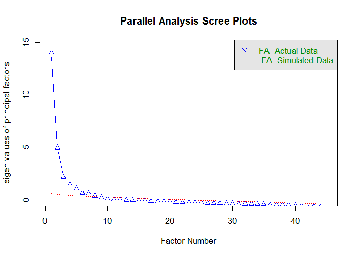

```
Parallel analysis suggests that the number of factors =  8  and the number of components =  NA
```

```r
ds_pa <- data.frame(
  observed_eigens = pa_results$fa.values,
  simulated_eigens = pa_results$fa.sim
) %>% head(15) %>% print()
```

```
   observed_eigens simulated_eigens
1     14.058670441        0.6230353
2      4.985410045        0.5037423
3      2.159309700        0.4571751
4      1.442010244        0.4231346
5      1.058692478        0.3907078
6      0.642168563        0.3580613
7      0.587735037        0.3304774
8      0.385927276        0.3047834
9      0.235506246        0.2801124
10     0.102261017        0.2561013
11     0.034752955        0.2337611
12     0.002964522        0.2082695
13    -0.021035732        0.1876315
14    -0.040372286        0.1633777
15    -0.089048394        0.1453386
```

## Fit

`psych::fa` call is applied to conduct maximum likelihood factor analysls (`fm="ml"`) in order to obtain the chi-square of the proposed models, which incrementally increase the number of retained factors. CFI and TLI indices are then computed from the produced criteria. For details on `psych::fa` see [documentation](https://www.rdocumentation.org/packages/psych/versions/1.6.9/topics/fa)

```r
ls_solution <- solve_factors(R3,min=1,max=15,sample_size = 643)
ds_index <- get_indices(ls_solution)
ds_index %>% print()
```

```
   n_factors chisq_null df_null      chisq  df        CFI
1          1   22721.04     990 25557.9339 945 -0.1326165
2          2   22721.04     990  8344.9922 901  0.6574489
3          3   22721.04     990  5155.8623 858  0.8022247
4          4   22721.04     990  3169.0071 816  0.8917214
5          5   22721.04     990  2189.8412 775  0.9348931
6          6   22721.04     990  1616.3575 735  0.9594425
7          7   22721.04     990  1202.0989 696  0.9767108
8          8   22721.04     990   974.7391 658  0.9854246
9          9   22721.04     990   712.9519 621  0.9957686
10        10   22721.04     990   538.6414 585  1.0021333
11        11   22721.04     990   407.5341 550  1.0065559
12        12   22721.04     990   340.8359 516  1.0080605
13        13   22721.04     990   291.3286 483  1.0088202
14        14   22721.04     990   230.1720 451  1.0101619
```

[output cut: 17 more lines]

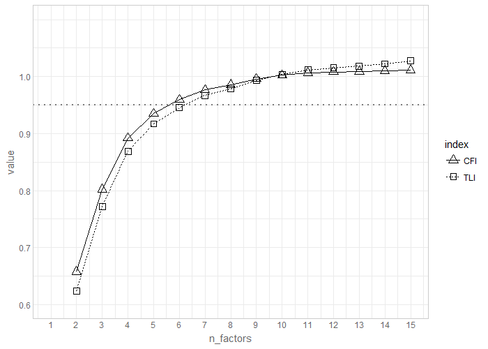

```r
ds_index %>% plot_fit_indices()
```

## RMSEA

RMSEA diagnostic is conducted using [Advanced Factor Function](http://statpower.net/Content/312/R%20Stuff/AdvancedFactorFunctions.txt) by James Steiger. The routine relies on the maxim likelihood factor analysis conducted by `stats::factanal` call. For details on the latter see [here](https://stat.ethz.ch/R-manual/R-devel/library/stats/html/factanal.html)

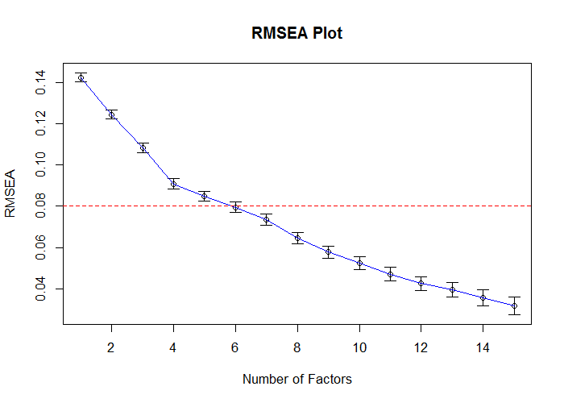

```
      Factors Cum.Eigen Chi-Square  Df      p.value   RMSEA.Pt
 [1,]       1  14.64875 13223.7249 945 0.000000e+00 0.14226341
 [2,]       2  20.49772  9849.7966 901 0.000000e+00 0.12438053
 [3,]       3  23.30151  7321.5114 858 0.000000e+00 0.10832360
 [4,]       4  25.28874  5144.8461 816 0.000000e+00 0.09090201
 [5,]       5  27.02017  4360.7671 775 0.000000e+00 0.08489315
 [6,]       6  28.41664  3717.1101 735 0.000000e+00 0.07949698
 [7,]       7  29.77374  3109.9461 696 0.000000e+00 0.07350073
 [8,]       8  30.80469  2419.6435 658 0.000000e+00 0.06457710
 [9,]       9  31.76782  1957.6662 621 0.000000e+00 0.05790261
[10,]      10  32.57468  1617.9716 585 0.000000e+00 0.05244435
[11,]      11  33.32850  1336.6346 550 0.000000e+00 0.04719953
[12,]      12  34.01778  1116.8090 516 0.000000e+00 0.04258688
[13,]      13  34.69023   969.0159 483 0.000000e+00 0.03958988
[14,]      14  35.34497   823.2240 451 0.000000e+00 0.03585472
```

[output cut: 17 more lines]

```r
FA.Stats(Correlation.Matrix = R3,n.obs = 643,n.factors = 1:15,RMSEA.cutoff = .08)
```

## Estimate

Using [Advanced Factor Function](http://statpower.net/Content/312/R%20Stuff/AdvancedFactorFunctions.txt) by James Steiger, we conduct maximum likelihood factor analysis, by obtaining the unrotated solution from `stats::factanal` call and then rotating solution using gradient projection algorithms (Bernaards & Jennrich, 2005).

```r
fit_efa_3 <- MLFA(
  Correlation.Matrix = R3,
  n.factors = 6,
  n.obs = 643,
  sort = FALSE
)
```

```
This will take a moment..........exiting
```

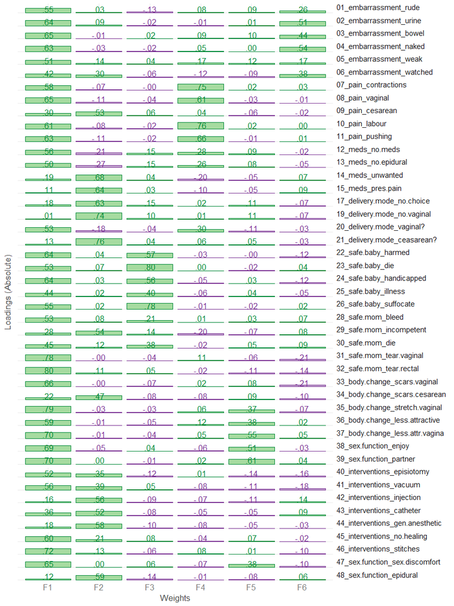

```r
#Loadings from the EFA solution\n")
f_pattern <- fit_efa_3[['Bifactor']]$F
f_pattern %>% plot_factor_pattern(factor_width = 6)
```

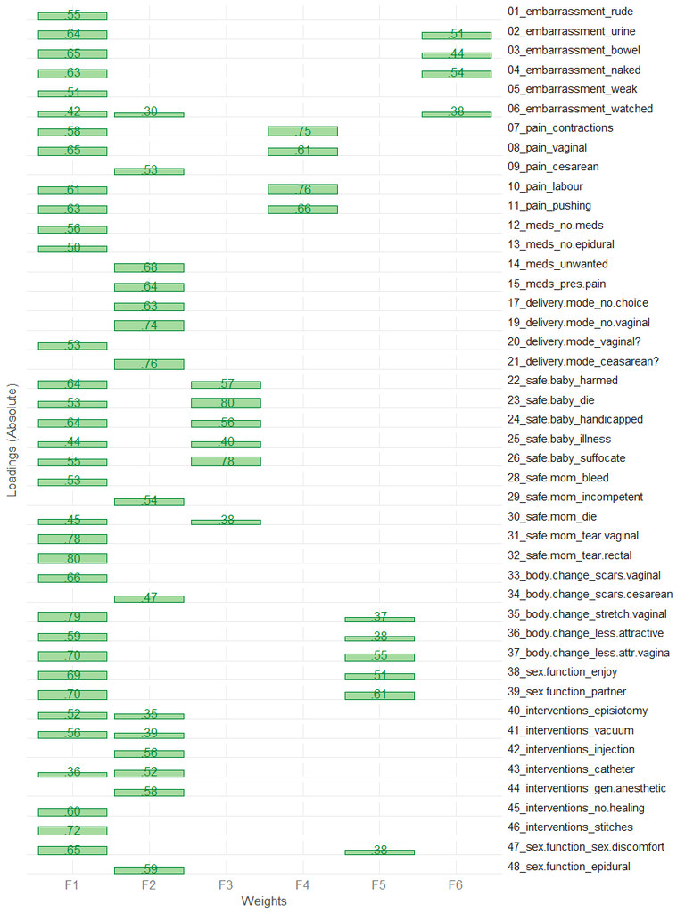

```r
# Loadings above threashold (.3) are masked to see the simpler structure
f_pattern[f_pattern<.30] <- NA
f_pattern %>% plot_factor_pattern(factor_width = 6)
```

## Confirm

Applying “Exploratory-Confirmatory” procedure described by [Joreskog(1978)](https://scholar.google.ca/scholar?q=Structural+analysis+of+covariance+and+correlation+matrices&btnG=&hl=en&as_sdt=0%2C33), we find the largest loading for each column of the factor pattern, then constrain all the other loadings in that row to be zero, and fit the resulting model as a confirmatory factor model. Given that we chose the orthogonal bifactor solution, we permit the the cross-loadings between general factor and subfactors.

NOTE: we chose to fix the loading of `item 6` on subscale 2 to `0` because it was borderline trivial (`.30`), and because it had substantial loadings on the subscale 6. We decided not to eliminate it from the scale because it had a strong conceptual fit to subscale 6 and contributed to the interpretability of the overall scale.

```r
# These values are translated into CFA model and used as starting values
model_3 <- FAtoSEM(
  x                 = fit_efa_3[["Bifactor"]] ,
  cutoff            = 0.31,
  factor.names      = c("General","Interventions","Safety","Pain","Sex & Body","Shame"),
  make.start.values = TRUE,
  cov.matrix        = FALSE, # TRUE - oblique, FALSE - orthogonal
  num.digits        = 4
)
```

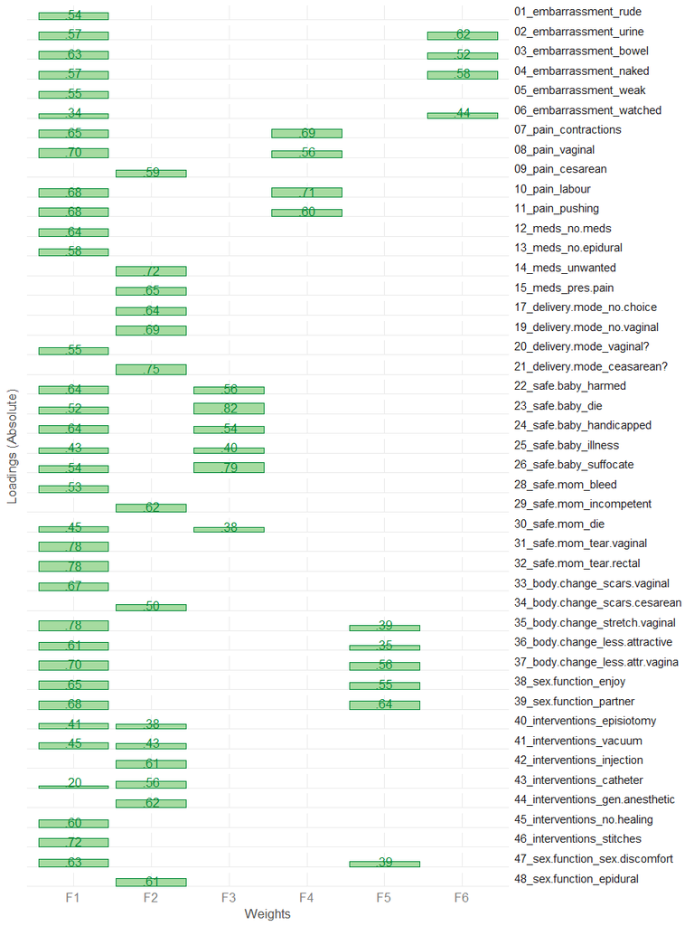

```r
# the model is estimated using sem package
fit_3 <- sem::sem(model_3,R3,sample_size)
# the pattern of the solution
m <- GetPattern(fit_3)$F
m[m==0] <- NA
m %>% plot_factor_pattern(factor_width=6)
```

```r
# Summary of the fitted model
sem_model_summary(fit_3)
```

```
Model Chiquare =  5361.8  | df model =  922  | df null =  990
Goodness-of-fit index =  0.7077978
Adjusted Goodness-of-fit index =  0.6719856
RMSEA index =  .0866           90% CI: (.084,.089)
Comparitive Fit Index (CFI = 0.8009555
Tucker Lewis Index (TLI/NNFI) =  0.7862754
Akaike Information Criterion (AIC) = 5587.8
Bayesian Information Criterion (BIC) = -599.9849
```

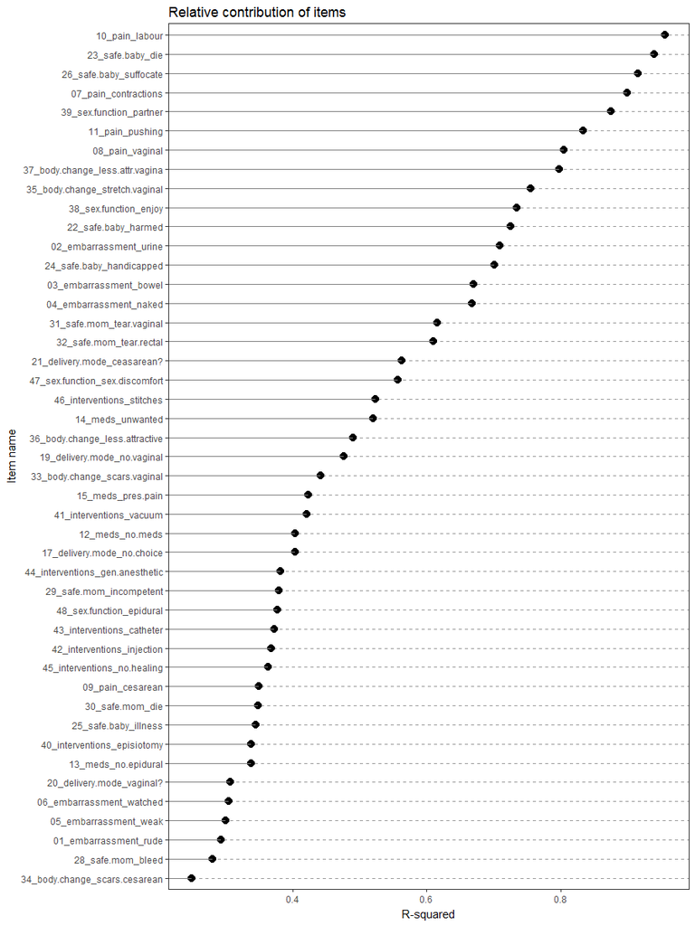

```r
#Relative contribudion of items
sort(summary(fit_3)$Rsq) %>% dot_plot()
```

# Phase 4

Based on the results from phase 3 we identified that `item 28` performs poorly on the scale, according to the consideration we have outlined. It does not have non-trivial loadings on any of the subscale (1), has a modest loading on the general factor(2), and has a relatively small R-square contribution(5).

Thus we removed `item 28` from the pool of items and repeat the analytical steps.

```r
drop_items_4 <- c("foc_28")
items_phase_4 <- setdiff(items_phase_3, drop_items_4)
R4 <- make_cor(ds, metaData, items_phase_4)
```

## Scree

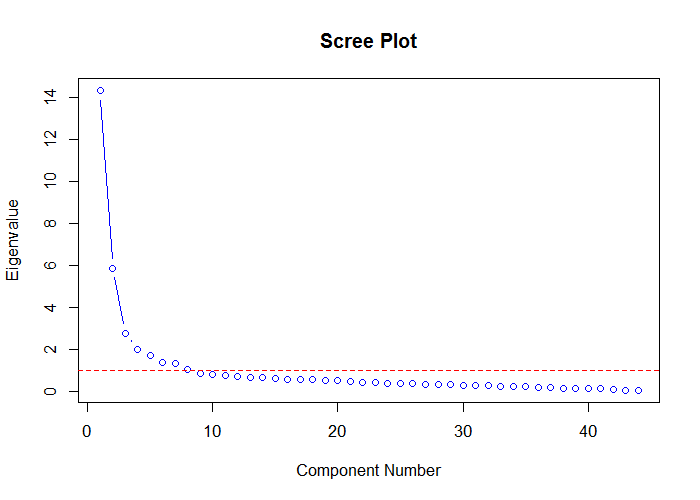

```r
# Diagnosing number of factors
Scree.Plot(R4)
```

```r
#The first 15 eigen values
data.frame(
  eigen = c(1:nrow(R4)),
  value = eigen(R4)$values
) %>%
  dplyr::filter(eigen < 16) %>%
  print()
```

```
   eigen      value
1      1 14.3240834
2      2  5.8485873
3      3  2.7589871
4      4  1.9863038
5      5  1.7204655
6      6  1.3897594
7      7  1.3239562
8      8  1.0274052
9      9  0.8489992
10    10  0.8041700
11    11  0.7456201
12    12  0.6879099
13    13  0.6724458
14    14  0.6388179
15    15  0.5979046
```

## MAP

`psych::nfactors` call is applied, producing Very Simple Structure, Velicer’s MAP, and other criteria to determine the appropriate number of factors. See [documentation](http://www.personality-project.org/r/html/VSS.html)

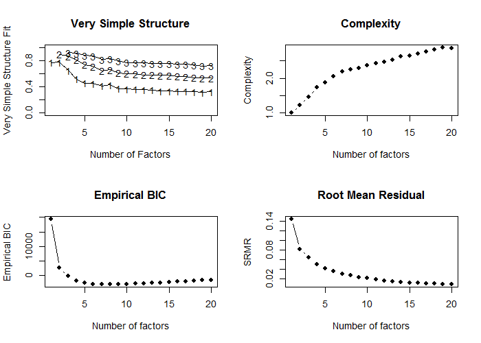

```
Number of factors
Call: vss(x = x, n = n, rotate = rotate, diagonal = diagonal, fm = fm,
    n.obs = n.obs, plot = FALSE, title = title, use = use, cor = cor)
VSS complexity 1 achieves a maximimum of 0.77  with  2  factors
VSS complexity 2 achieves a maximimum of 0.9  with  2  factors
The Velicer MAP achieves a minimum of 0.01  with  8  factors
Empirical BIC achieves a minimum of  -3181.92  with  7  factors
Sample Size adjusted BIC achieves a minimum of  -656.88  with  14  factors

Statistics by number of factors
   vss1 vss2   map dof chisq     prob sqresid  fit RMSEA   BIC
1  0.77 0.00 0.040 902 13025  0.0e+00    61.9 0.77 0.147  7193
2  0.77 0.90 0.025 859  9653  0.0e+00    27.3 0.90 0.128  4099
3  0.65 0.87 0.022 817  7188  0.0e+00    20.6 0.92 0.112  1905
4  0.52 0.81 0.016 776  4997  0.0e+00    16.1 0.94 0.094   -20
```

[output cut: 37 more lines]

```r
# MAP
psych::nfactors(R4,n.obs = 643)
```

## Parallel

`psych::fa.parallel` call is applied, comparing the number of factors in the correlation matrix to random “parallel” matrices. For details, see [documentation](https://www.rdocumentation.org/packages/psych/versions/1.6.9/topics/fa.parallel?)

```r
pa_results <- psych::fa.parallel(R4,643,fm = "ml",fa="fa")
```

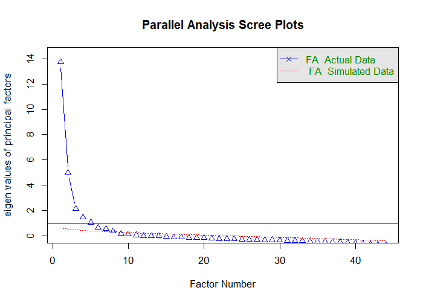

```
Parallel analysis suggests that the number of factors =  8  and the number of components =  NA
```

```r
ds_pa <- data.frame(
  observed_eigens = pa_results$fa.values,
  simulated_eigens = pa_results$fa.sim
) %>% head(15) %>% print()
```

```
   observed_eigens simulated_eigens
1      13.73717088        0.5837231
2       4.98409850        0.4925928
3       2.11160620        0.4540632
4       1.44444157        0.4150139
5       1.04706370        0.3790366
6       0.64272471        0.3522506
7       0.54265829        0.3213032
8       0.35350708        0.2933733
9       0.15896605        0.2685265
10      0.10302055        0.2475262
11      0.03236708        0.2178965
12     -0.01975138        0.1958912
13     -0.03073731        0.1758729
14     -0.04237818        0.1561653
15     -0.09141584        0.1333218
```

## Fit

`psych::fa` call is applied to conduct maximum likelihood factor analysls (`fm="ml"`) in order to obtain the chi-square of the proposed models, which incrementally increase the number of retained factors. CFI and TLI indices are then computed from the produced criteria. For details on `psych::fa` see [documentation](https://www.rdocumentation.org/packages/psych/versions/1.6.9/topics/fa)

```r
ls_solution <- solve_factors(R4,min=1,max=15,sample_size = 643)
ds_index <- get_indices(ls_solution)
ds_index %>% print()
```

```
   n_factors chisq_null df_null      chisq  df        CFI
1          1   22310.05     946 25300.8085 902 -0.1420496
2          2   22310.05     946  8067.2858 859  0.6625975
3          3   22310.05     946  5001.0721 817  0.8041536
4          4   22310.05     946  3022.9844 776  0.8948241
5          5   22310.05     946  2045.3943 736  0.9387104
6          6   22310.05     946  1502.5982 697  0.9622919
7          7   22310.05     946  1079.2691 659  0.9803282
8          8   22310.05     946   882.5096 622  0.9878062
9          9   22310.05     946   613.5776 586  0.9987092
10        10   22310.05     946   506.4825 551  1.0020838
11        11   22310.05     946   376.4499 517  1.0065788
12        12   22310.05     946   305.2191 484  1.0083683
13        13   22310.05     946   246.7056 452  1.0096093
14        14   22310.05     946   183.4404 421  1.0111196
```

[output cut: 17 more lines]

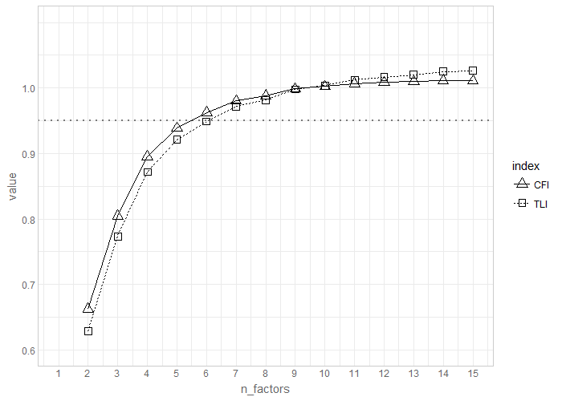

```r
ds_index %>% plot_fit_indices()
```

## RMSEA

RMSEA diagnostic is conducted using [Advanced Factor Function](http://statpower.net/Content/312/R%20Stuff/AdvancedFactorFunctions.txt) by James Steiger. The routine relies on the maxim likelihood factor analysis conducted by `stats::factanal` call. For details on the latter see [here](https://stat.ethz.ch/R-manual/R-devel/library/stats/html/factanal.html)

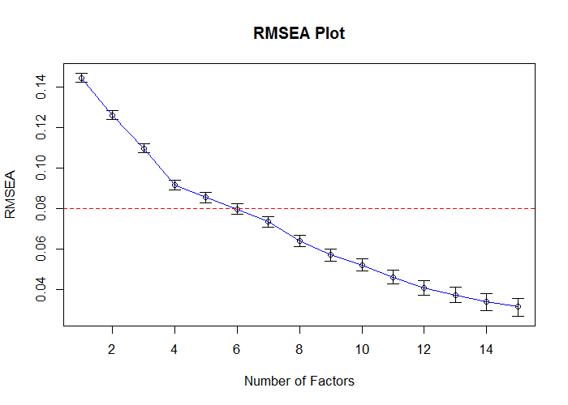

```
      Factors Cum.Eigen Chi-Square  Df      p.value   RMSEA.Pt
 [1,]       1  14.32408 13025.1688 902 0.000000e+00 0.14468959
 [2,]       2  20.17267  9650.7716 859 0.000000e+00 0.12626242
 [3,]       3  22.93166  7143.6228 817 0.000000e+00 0.10982657
 [4,]       4  24.91796  4966.7400 776 0.000000e+00 0.09171640
 [5,]       5  26.63843  4187.2874 736 0.000000e+00 0.08546418
 [6,]       6  28.02819  3544.0994 697 0.000000e+00 0.07976593
 [7,]       7  29.35214  2940.7987 659 0.000000e+00 0.07343928
 [8,]       8  30.37955  2252.7348 622 0.000000e+00 0.06390414
 [9,]       9  31.22855  1810.9567 586 0.000000e+00 0.05706161
[10,]      10  32.03272  1507.6455 551 0.000000e+00 0.05200346
[11,]      11  32.77834  1219.7354 517 0.000000e+00 0.04601327
[12,]      12  33.46625  1000.8388 484 0.000000e+00 0.04078377
[13,]      13  34.13869   854.0272 452 0.000000e+00 0.03722125
[14,]      14  34.77751   726.7271 421 0.000000e+00 0.03363244
```

[output cut: 17 more lines]

```r
FA.Stats(Correlation.Matrix = R4,n.obs = 643,n.factors = 1:15,RMSEA.cutoff = .08)
```

## Estimate

Using [Advanced Factor Function](http://statpower.net/Content/312/R%20Stuff/AdvancedFactorFunctions.txt) by James Steiger, we conduct maximum likelihood factor analysis, by obtaining the unrotated solution from `stats::factanal` call and then rotating solution using gradient projection algorithms (Bernaards & Jennrich, 2005).

```r
fit_efa_4 <- MLFA(
  Correlation.Matrix = R4,
  n.factors = 6,
  n.obs = 643,
  sort = FALSE
)
```

```
This will take a moment..........exiting
```

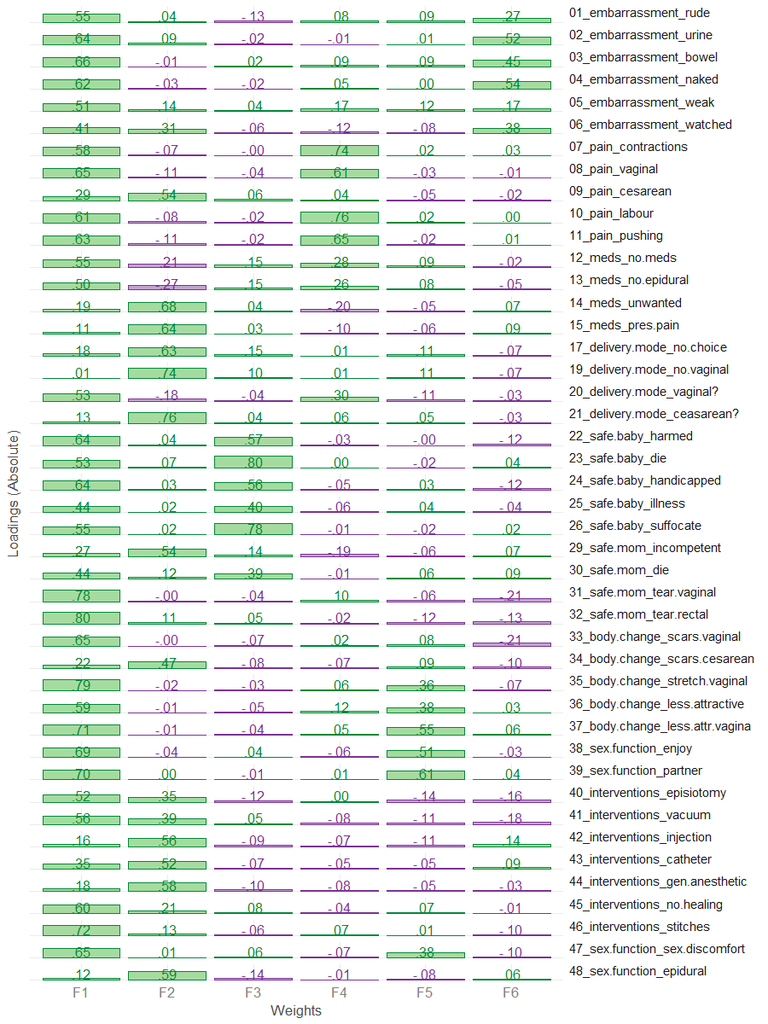

```r
#Loadings from the EFA solution\n")
f_pattern <- fit_efa_4[['Bifactor']]$F
f_pattern %>% plot_factor_pattern(factor_width = 6)
```

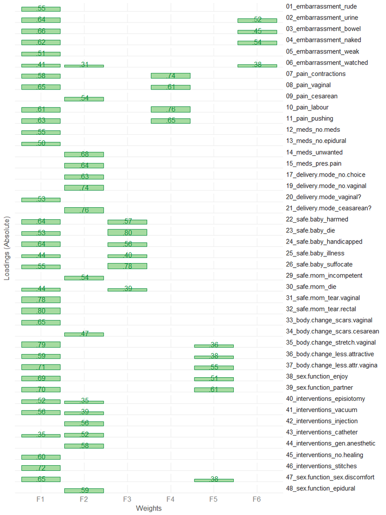

```r
# Loadings above threashold (.3) are masked to see the simpler structure
f_pattern[f_pattern<.30] <- NA
f_pattern %>% plot_factor_pattern(factor_width = 6)
```

## Confirm

Applying “Exploratory-Confirmatory” procedure described by [Joreskog(1978)](https://scholar.google.ca/scholar?q=Structural+analysis+of+covariance+and+correlation+matrices&btnG=&hl=en&as_sdt=0%2C33), we find the largest loading for each column of the factor pattern, then constrain all the other loadings in that row to be zero, and fit the resulting model as a confirmatory factor model. Given that we chose the orthogonal bifactor solution, we permit the the cross-loadings between general factor and subfactors.

NOTE: we chose to fix the loading of `item 6` on subscale 2 to `0` because it was borderline trivial (`.31`), and because it had substantial loadings on the subscale 6. We decided not to eliminate it from the scale because it had a strong conceptual fit to subscale 6 and contributed to the interpretability of the overall scale.

```r
# These values are translated into CFA model and used as starting values
model_4 <- FAtoSEM(
  x                 = fit_efa_4[["Bifactor"]] ,
  cutoff            = 0.31,
  factor.names      = c("General","Interventions","Safety","Pain","Sex & Body","Shame"),
  make.start.values = TRUE,
  cov.matrix        = FALSE, # TRUE - oblique, FALSE - orthogonal
  num.digits        = 4
)
```

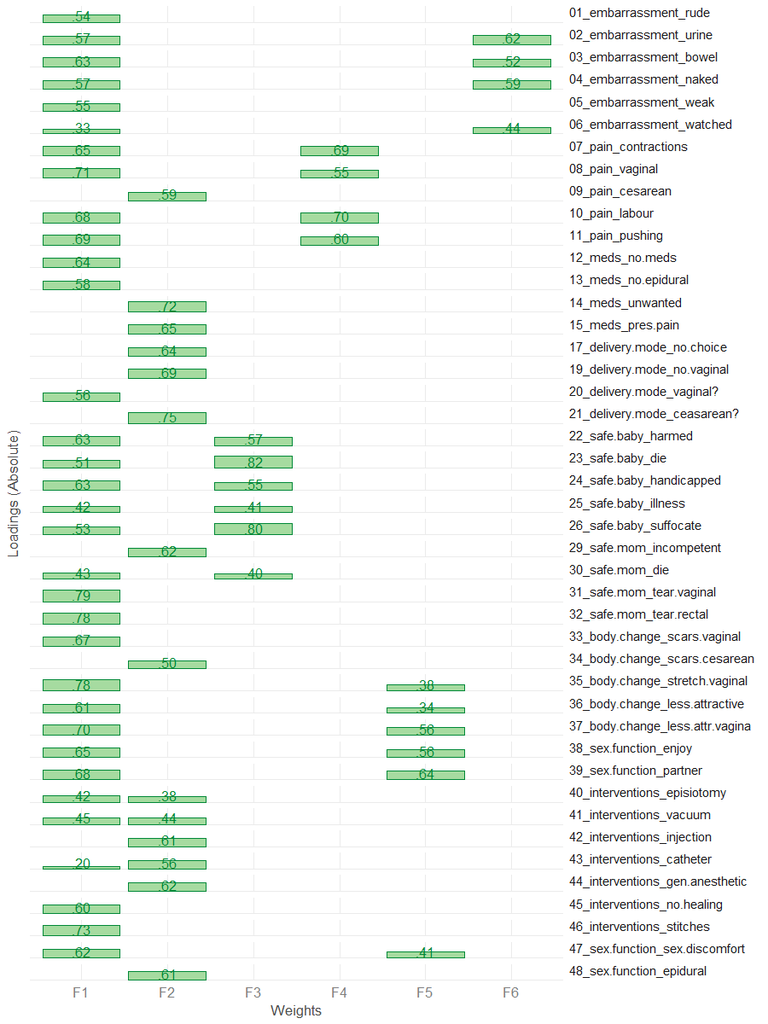

```r
# the model is estimated using sem package
fit_4 <- sem::sem(model_4,R4,sample_size)
# the pattern of the solution
m <- GetPattern(fit_4)$F
m[m==0] <- NA
m %>% plot_factor_pattern(factor_width=6)
```

```r
# Summary of the fitted model
sem_model_summary(fit_4)
```

```
Model Chiquare =  5121.14  | df model =  879  | df null =  946
Goodness-of-fit index =  0.7148281
Adjusted Goodness-of-fit index =  0.6788166
RMSEA index =  .0867           90% CI: (.084,.089)
Comparitive Fit Index (CFI = 0.8064366
Tucker Lewis Index (TLI/NNFI) =  0.7916826
Akaike Information Criterion (AIC) = 5343.14
Bayesian Information Criterion (BIC) = -562.6013
```

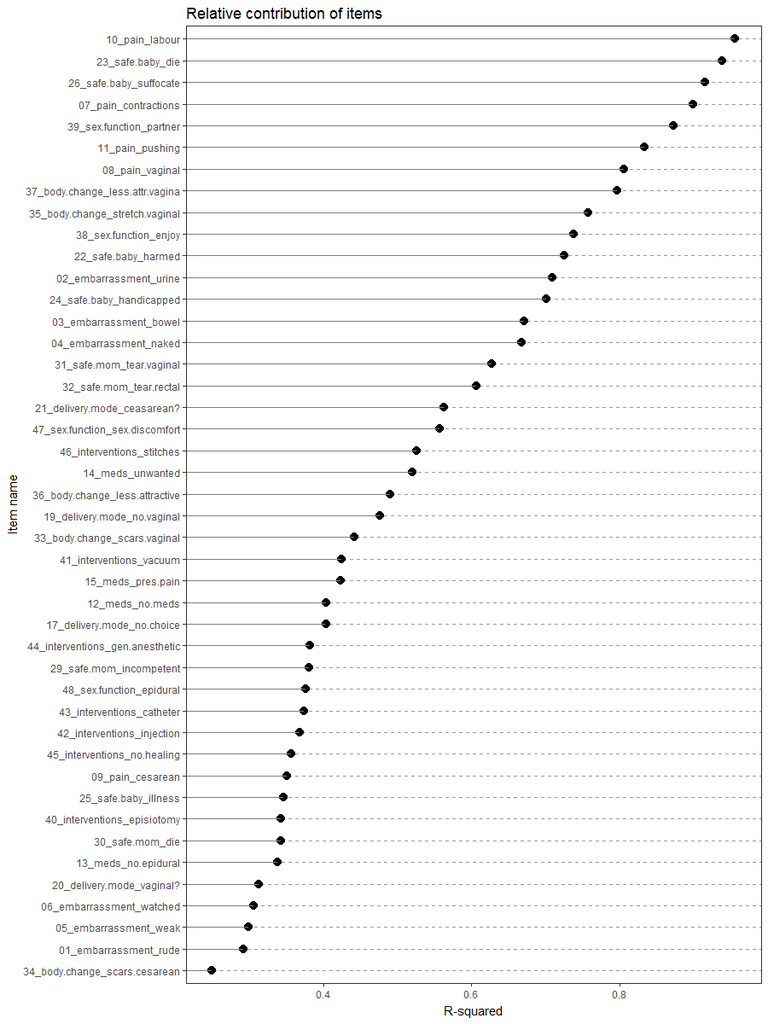

```r
#Relative contribudion of items
sort(summary(fit_4)$Rsq) %>% dot_plot()
```

# Phase 5

Based on the results from phase 3 we identified that `item 5` performs poorly on the scale, according to the consideration we have outlined. It does not have non-trivial loadings on any of the subscale (1), has a modest loading on the general factor(2), and has a relatively small R-square contribution(5).

Thus we removed `item 5` from the pool of items and repeat the analytical steps.

```r
drop_items_5 <- c("foc_05")
items_phase_5 <- setdiff(items_phase_4, drop_items_5)
R5 <- make_cor(ds, metaData, items_phase_5)
```

## Scree

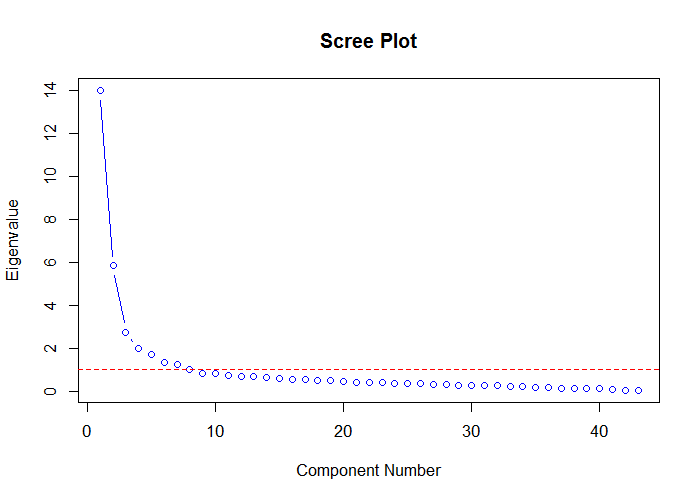

```r
# Diagnosing number of factors
Scree.Plot(R5)
```

```r
#The first 15 eigen values
data.frame(
  eigen = c(1:nrow(R5)),
  value = eigen(R5)$values
) %>%
  dplyr::filter(eigen < 16) %>%
  print()
```

```
   eigen      value
1      1 13.9937705
2      2  5.8485737
3      3  2.7530230
4      4  1.9861503
5      5  1.7072120
6      6  1.3495091
7      7  1.2617484
8      8  1.0211763
9      9  0.8488369
10    10  0.8030910
11    11  0.7321124
12    12  0.6872050
13    13  0.6643892
14    14  0.6281910
15    15  0.5933009
```

## MAP

`psych::nfactors` call is applied, producing Very Simple Structure, Velicer’s MAP, and other criteria to determine the appropriate number of factors. See [documentation](http://www.personality-project.org/r/html/VSS.html)

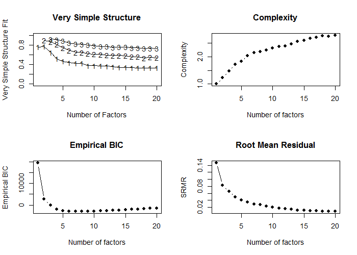

```
Number of factors
Call: vss(x = x, n = n, rotate = rotate, diagonal = diagonal, fm = fm,
    n.obs = n.obs, plot = FALSE, title = title, use = use, cor = cor)
VSS complexity 1 achieves a maximimum of 0.77  with  2  factors
VSS complexity 2 achieves a maximimum of 0.9  with  2  factors
The Velicer MAP achieves a minimum of 0.01  with  8  factors
Empirical BIC achieves a minimum of  -3015.61  with  7  factors
Sample Size adjusted BIC achieves a minimum of  -585.82  with  14  factors

Statistics by number of factors
   vss1 vss2   map dof chisq     prob sqresid  fit RMSEA   BIC
1  0.76 0.00 0.042 860 12930  0.0e+00    61.2 0.76 0.150  7369
2  0.77 0.90 0.026 818  9564  0.0e+00    26.6 0.90 0.131  4275
3  0.65 0.87 0.022 777  7094  0.0e+00    20.0 0.92 0.114  2070
4  0.52 0.81 0.017 737  4906  0.0e+00    15.5 0.94 0.095   140
```

[output cut: 37 more lines]

```r
# MAP
psych::nfactors(R5,n.obs = 643)
```

## Parallel

`psych::fa.parallel` call is applied, comparing the number of factors in the correlation matrix to random “parallel” matrices. For details, see [documentation](https://www.rdocumentation.org/packages/psych/versions/1.6.9/topics/fa.parallel?)

```r
pa_results <- psych::fa.parallel(R5,643,fm = "ml",fa="fa")
```

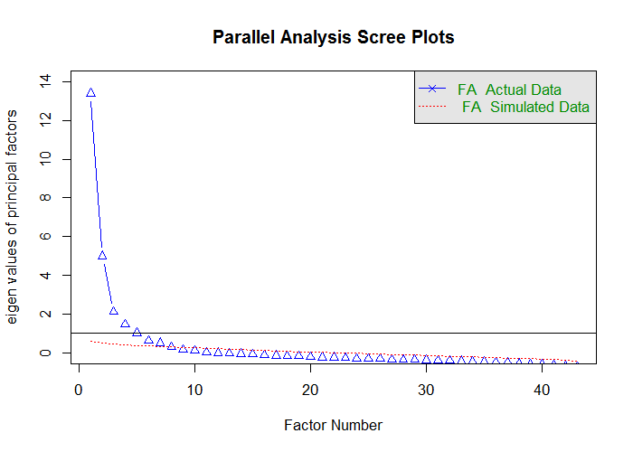

```
Parallel analysis suggests that the number of factors =  8  and the number of components =  NA
```

```r
ds_pa <- data.frame(
  observed_eigens = pa_results$fa.values,
  simulated_eigens = pa_results$fa.sim
) %>% head(15) %>% print()
```

```
   observed_eigens simulated_eigens
1     13.409132874        0.5673612
2      4.983414832        0.4798019
3      2.106034339        0.4326137
4      1.444644011        0.4033911
5      1.022113644        0.3755231
6      0.627427125        0.3474271
7      0.494522349        0.3162965
8      0.303714564        0.2890521
9      0.153846436        0.2623993
10     0.103496336        0.2409275
11     0.006408525        0.2160117
12    -0.019857351        0.1934735
13    -0.033101598        0.1718222
14    -0.053269349        0.1493397
15    -0.093190585        0.1300472
```

## Fit

`psych::fa` call is applied to conduct maximum likelihood factor analysls (`fm="ml"`) in order to obtain the chi-square of the proposed models, which incrementally increase the number of retained factors. CFI and TLI indices are then computed from the produced criteria. For details on `psych::fa` see [documentation](https://www.rdocumentation.org/packages/psych/versions/1.6.9/topics/fa)

```r
ls_solution <- solve_factors(R5,min=1,max=15,sample_size = 643)
ds_index <- get_indices(ls_solution)
ds_index %>% print()
```

```
   n_factors chisq_null df_null      chisq  df        CFI
1          1   21986.15     903 25150.6363 860 -0.1521349
2          2   21986.15     903  7917.1765 818  0.6632773
3          3   21986.15     903  4886.3462 777  0.8050886
4          4   21986.15     903  2896.0445 737  0.8975938
5          5   21986.15     903  1945.0540 698  0.9408507
6          6   21986.15     903  1438.6500 660  0.9630677
7          7   21986.15     903  1012.8028 623  0.9815112
8          8   21986.15     903   861.8346 587  0.9869643
9          9   21986.15     903   600.2811 552  0.9977100
10        10   21986.15     903   492.7624 518  1.0011971
11        11   21986.15     903   363.2638 485  1.0057741
12        12   21986.15     903   292.2585 453  1.0076242
13        13   21986.15     903   235.8425 422  1.0088297
14        14   21986.15     903   170.8848 392  1.0104878
```

[output cut: 17 more lines]

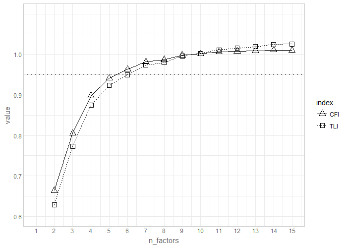

```r
ds_index %>% plot_fit_indices()
```

## RMSEA

RMSEA diagnostic is conducted using [Advanced Factor Function](http://statpower.net/Content/312/R%20Stuff/AdvancedFactorFunctions.txt) by James Steiger. The routine relies on the maxim likelihood factor analysis conducted by `stats::factanal` call. For details on the latter see [here](https://stat.ethz.ch/R-manual/R-devel/library/stats/html/factanal.html)

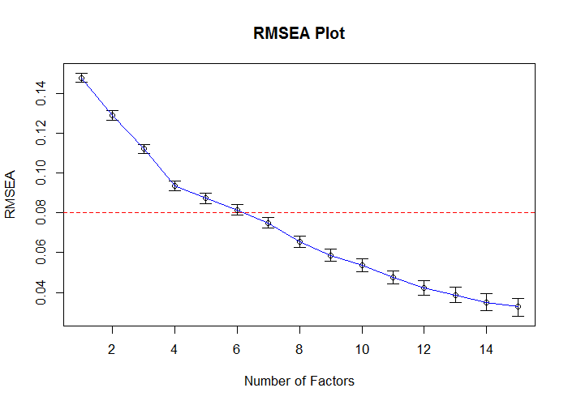

```
      Factors Cum.Eigen Chi-Square  Df      p.value   RMSEA.Pt
 [1,]       1  13.99377 12930.1304 860 0.000000e+00 0.14785610
 [2,]       2  19.84234  9561.7857 818 0.000000e+00 0.12903442
 [3,]       3  22.59537  7050.1229 777 0.000000e+00 0.11214086
 [4,]       4  24.58152  4875.2856 737 0.000000e+00 0.09352096
 [5,]       5  26.28873  4112.5593 698 0.000000e+00 0.08729153
 [6,]       6  27.63824  3471.7930 660 0.000000e+00 0.08146146
 [7,]       7  28.89999  2874.9150 623 0.000000e+00 0.07503510
 [8,]       8  29.92116  2199.0201 587 0.000000e+00 0.06540315
 [9,]       9  30.77000  1774.4539 552 0.000000e+00 0.05873260
[10,]      10  31.57309  1470.7884 518 0.000000e+00 0.05352613
[11,]      11  32.30520  1189.7536 485 0.000000e+00 0.04757516
[12,]      12  32.99241   976.2787 453 0.000000e+00 0.04241797
[13,]      13  33.65680   829.8782 422 0.000000e+00 0.03880087
[14,]      14  34.28499   702.2533 392 0.000000e+00 0.03511136
```

[output cut: 17 more lines]

```r
FA.Stats(Correlation.Matrix = R5,n.obs = 643,n.factors = 1:15,RMSEA.cutoff = .08)
```

## Estimate

Using [Advanced Factor Function](http://statpower.net/Content/312/R%20Stuff/AdvancedFactorFunctions.txt) by James Steiger, we conduct maximum likelihood factor analysis, by obtaining the unrotated solution from `stats::factanal` call and then rotating solution using gradient projection algorithms (Bernaards & Jennrich, 2005).

```r
fit_efa_5 <- MLFA(
  Correlation.Matrix = R5,
  n.factors = 6,
  n.obs = 643,
  sort = FALSE
)
```

```
This will take a moment..........exiting
```

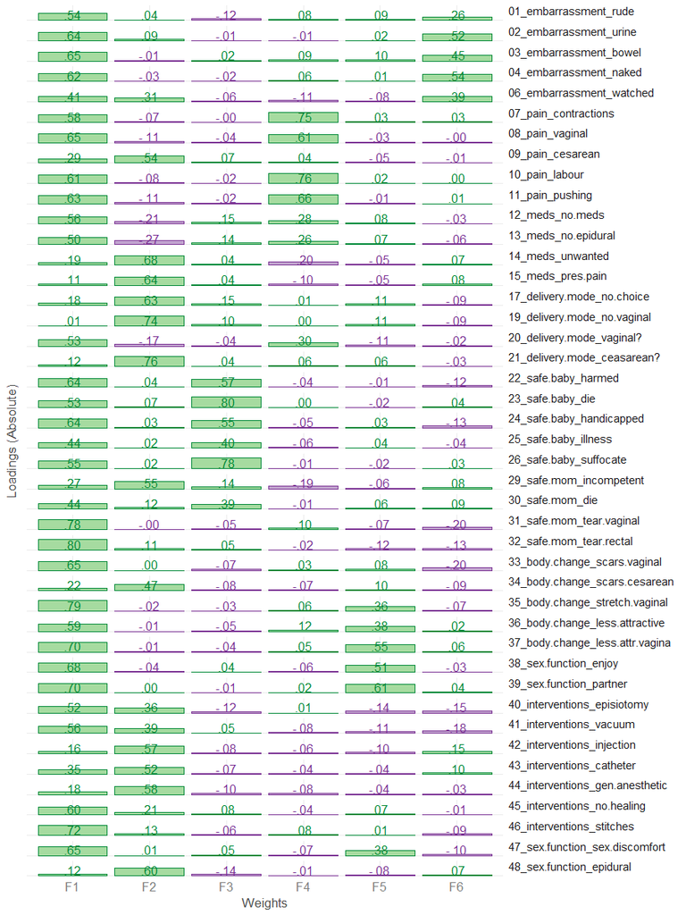

```r
#Loadings from the EFA solution\n")
f_pattern <- fit_efa_5[['Bifactor']]$F
f_pattern %>% plot_factor_pattern(factor_width = 6)
```

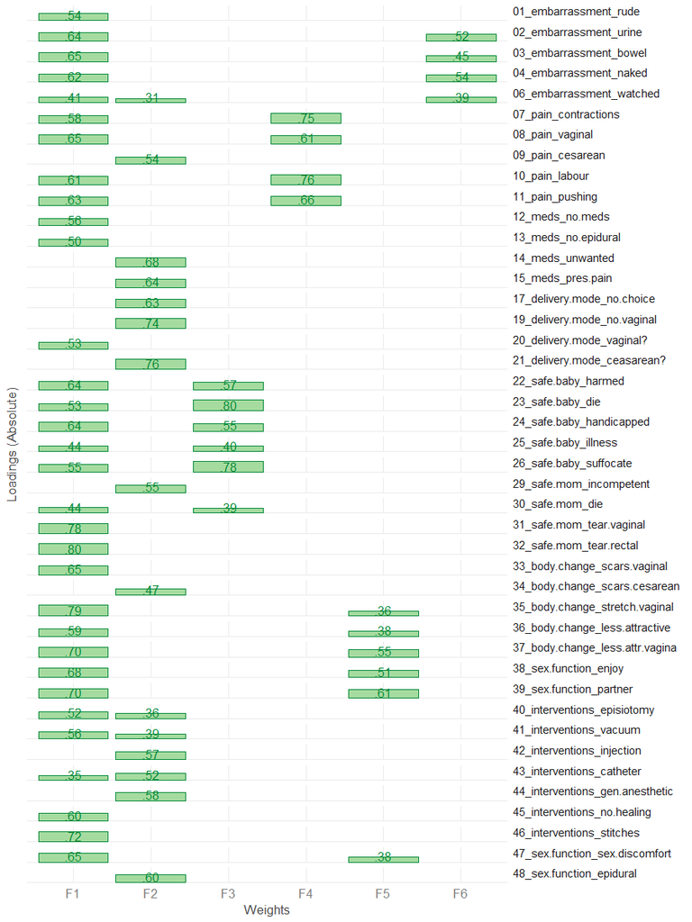

```r
# Loadings above threashold (.3) are masked to see the simpler structure
f_pattern[f_pattern<.30] <- NA
f_pattern %>% plot_factor_pattern(factor_width = 6)
```

## Confirm

Applying “Exploratory-Confirmatory” procedure described by [Joreskog(1978)](https://scholar.google.ca/scholar?q=Structural+analysis+of+covariance+and+correlation+matrices&btnG=&hl=en&as_sdt=0%2C33), we find the largest loading for each column of the factor pattern, then constrain all the other loadings in that row to be zero, and fit the resulting model as a confirmatory factor model. Given that we chose the orthogonal bifactor solution, we permit the the cross-loadings between general factor and subfactors.

NOTE: we chose to fix the loading of `item 6` on subscale 2 to `0` because it was borderline trivial (`.31`), and because it had substantial loadings on the subscale 6. We decided not to eliminate it from the scale because it had a strong conceptual fit to subscale 6 and contributed to the interpretability of the overall scale.

```r
# These values are translated into CFA model and used as starting values
model_5 <- FAtoSEM(
  x                 = fit_efa_5[["Bifactor"]] ,
  cutoff            = 0.315,
  factor.names      = c("General","Interventions","Safety","Pain","Sex & Body","Shame"),
  make.start.values = TRUE,
  cov.matrix        = FALSE, # TRUE - oblique, FALSE - orthogonal
  num.digits        = 4
)
```

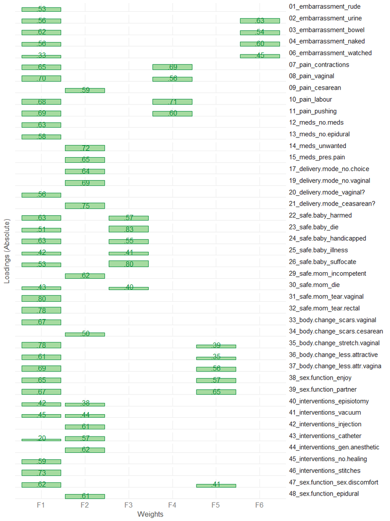

```r
# the model is estimated using sem package
fit_5 <- sem::sem(model_5,R5,sample_size)
# the pattern of the solution
m <- GetPattern(fit_5)$F
m[m==0] <- NA
m %>% plot_factor_pattern(factor_width=6)
```

```r
# Summary of the fitted model
sem_model_summary(fit_5)
```

```
Model Chiquare =  4985.451  | df model =  837  | df null =  903
Goodness-of-fit index =  0.7175682
Adjusted Goodness-of-fit index =  0.680788
RMSEA index =  .0879           90% CI: (.086,.090)
Comparitive Fit Index (CFI = 0.8080764
Tucker Lewis Index (TLI/NNFI) =  0.7929427
Akaike Information Criterion (AIC) = 5203.451
Bayesian Information Criterion (BIC) = -426.7118
```

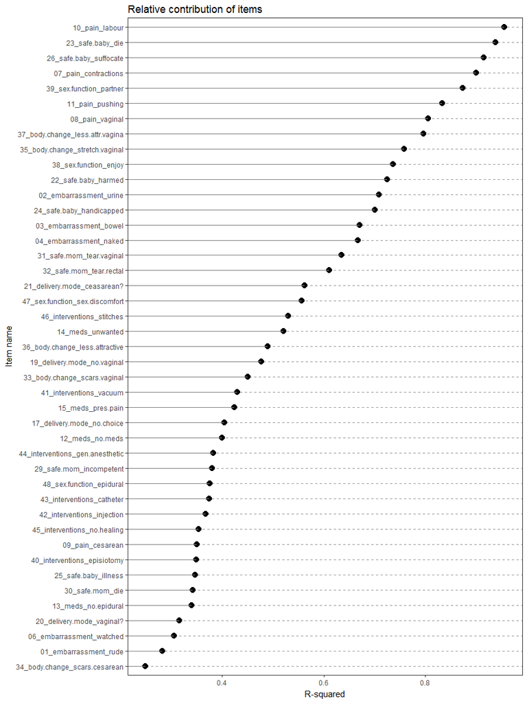

```r
#Relative contribudion of items
sort(summary(fit_5)$Rsq) %>% dot_plot()
```

# Conclusion

The remaining items do not violate the consideraton we have outlined.

One contention item is `item 6` which consistently exhibits crossloading between subscale 2 and subscale 6. Given that one of the loadings is borderline trivial (.31) and that `item 6` has a good conceptual fit to subscale 6, we chose to fix the loadings of `item 6` on subscale 2 to `0`, instead of eliminating it from the scale.

Thus the remaing simple structure the we recommend as the final solution is as follow:

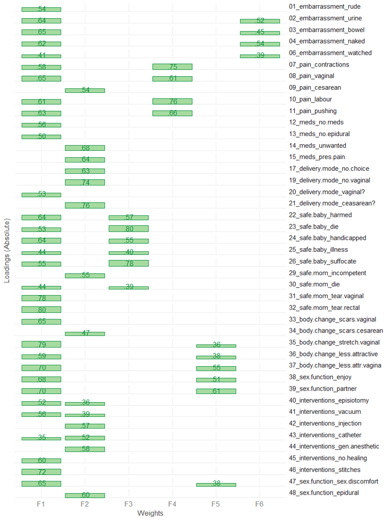

```r
f_pattern <- fit_efa_5[['Bifactor']]$F
f_pattern[f_pattern<.315] <- NA
f_pattern %>% plot_factor_pattern(factor_width = 6)
```

```r
# in tabular form with trival loading masked
f_pattern %>%
  knitr::kable(
    format = "pandoc",
    col.names = c("General","Interventions","Safety","Pain","Sex & Body","Shame")
    ) %>%
  print()
```

```
                                     General   Interventions      Safety        Pain   Sex & Body       Shame
--------------------------------  ----------  --------------  ----------  ----------  -----------  ----------
01_embarrassment_rude              0.5423311              NA          NA          NA           NA          NA
02_embarrassment_urine             0.6360442              NA          NA          NA           NA   0.5191268
03_embarrassment_bowel             0.6524832              NA          NA          NA           NA   0.4453735
04_embarrassment_naked             0.6197270              NA          NA          NA           NA   0.5421239
06_embarrassment_watched           0.4102923              NA          NA          NA           NA   0.3885364
07_pain_contractions               0.5792025              NA          NA   0.7472453           NA          NA
08_pain_vaginal                    0.6510848              NA          NA   0.6142756           NA          NA
09_pain_cesarean                          NA       0.5399706          NA          NA           NA          NA
10_pain_labour                     0.6059649              NA          NA   0.7589787           NA          NA
11_pain_pushing                    0.6304265              NA          NA   0.6557543           NA          NA
12_meds_no.meds                    0.5559427              NA          NA          NA           NA          NA
13_meds_no.epidural                0.5044168              NA          NA          NA           NA          NA
14_meds_unwanted                          NA       0.6820272          NA          NA           NA          NA
15_meds_pres.pain                         NA       0.6355912          NA          NA           NA          NA
17_delivery.mode_no.choice                NA       0.6270103          NA          NA           NA          NA
19_delivery.mode_no.vaginal               NA       0.7357646          NA          NA           NA          NA
20_delivery.mode_vaginal?          0.5310810              NA          NA          NA           NA          NA
21_delivery.mode_ceasarean?               NA       0.7644858          NA          NA           NA          NA
22_safe.baby_harmed                0.6426476              NA   0.5674386          NA           NA          NA
23_safe.baby_die                   0.5285097              NA   0.8038717          NA           NA          NA
24_safe.baby_handicapped           0.6397040              NA   0.5516328          NA           NA          NA
25_safe.baby_illness               0.4386072              NA   0.3980393          NA           NA          NA
26_safe.baby_suffocate             0.5508341              NA   0.7801998          NA           NA          NA
29_safe.mom_incompetent                   NA       0.5475148          NA          NA           NA          NA
30_safe.mom_die                    0.4403422              NA   0.3855353          NA           NA          NA
31_safe.mom_tear.vaginal           0.7821548              NA          NA          NA           NA          NA
32_safe.mom_tear.rectal            0.8018140              NA          NA          NA           NA          NA
33_body.change_scars.vaginal       0.6538025              NA          NA          NA           NA          NA
34_body.change_scars.cesarean             NA       0.4706666          NA          NA           NA          NA
35_body.change_stretch.vaginal     0.7877220              NA          NA          NA    0.3639712          NA
36_body.change_less.attractive     0.5902950              NA          NA          NA    0.3754984          NA
37_body.change_less.attr.vagina    0.7047113              NA          NA          NA    0.5502115          NA
38_sex.function_enjoy              0.6845786              NA          NA          NA    0.5136808          NA
39_sex.function_partner            0.6977852              NA          NA          NA    0.6099534          NA
40_interventions_episiotomy        0.5190803       0.3561446          NA          NA           NA          NA
41_interventions_vacuum            0.5623871       0.3907159          NA          NA           NA          NA
42_interventions_injection                NA       0.5677994          NA          NA           NA          NA
43_interventions_catheter          0.3476118       0.5249389          NA          NA           NA          NA
44_interventions_gen.anesthetic           NA       0.5834467          NA          NA           NA          NA
45_interventions_no.healing        0.5974308              NA          NA          NA           NA          NA
46_interventions_stitches          0.7191897              NA          NA          NA           NA          NA
47_sex.function_sex.discomfort     0.6514171              NA          NA          NA    0.3793449          NA
48_sex.function_epidural                  NA       0.5965350          NA          NA           NA          NA
```

```r
# in tabular form with trival loading not masked
fit_efa_5[['Bifactor']]$F  %>%
  knitr::kable()
```

|  | Factor1 | Factor2 | Factor3 | Factor4 | Factor5 | Factor6 |
| --- | --- | --- | --- | --- | --- | --- |
| 01_embarrassment_rude | 0.5423311 | 0.0354236 | -0.1244911 | 0.0804375 | 0.0929838 | 0.2630107 |
| 02_embarrassment_urine | 0.6360442 | 0.0917075 | -0.0138126 | -0.0077291 | 0.0161927 | 0.5191268 |
| 03_embarrassment_bowel | 0.6524832 | -0.0111220 | 0.0215508 | 0.0944602 | 0.0957132 | 0.4453735 |
| 04_embarrassment_naked | 0.6197270 | -0.0270492 | -0.0159298 | 0.0594531 | 0.0063320 | 0.5421239 |
| 06_embarrassment_watched | 0.4102923 | 0.3109858 | -0.0564087 | -0.1140143 | -0.0767534 | 0.3885364 |
| 07_pain_contractions | 0.5792025 | -0.0717081 | -0.0033736 | 0.7472453 | 0.0258658 | 0.0254427 |
| 08_pain_vaginal | 0.6510848 | -0.1050602 | -0.0358714 | 0.6142756 | -0.0258544 | -0.0030055 |
| 09_pain_cesarean | 0.2867441 | 0.5399706 | 0.0667467 | 0.0436430 | -0.0470758 | -0.0070998 |
| 10_pain_labour | 0.6059649 | -0.0799260 | -0.0196979 | 0.7589787 | 0.0171550 | 0.0023754 |
| 11_pain_pushing | 0.6304265 | -0.1071267 | -0.0218414 | 0.6557543 | -0.0148236 | 0.0102652 |
| 12_meds_no.meds | 0.5559427 | -0.2135850 | 0.1508779 | 0.2763704 | 0.0846084 | -0.0258057 |
| 13_meds_no.epidural | 0.5044168 | -0.2694987 | 0.1423887 | 0.2556412 | 0.0735463 | -0.0571148 |
| 14_meds_unwanted | 0.1865164 | 0.6820272 | 0.0409597 | -0.2032967 | -0.0486404 | 0.0661181 |
| 15_meds_pres.pain | 0.1117356 | 0.6355912 | 0.0353909 | -0.0984595 | -0.0543588 | 0.0849438 |
| 17_delivery.mode_no.choice | 0.1766746 | 0.6270103 | 0.1474796 | 0.0101480 | 0.1055107 | -0.0853591 |
| 19_delivery.mode_no.vaginal | 0.0104149 | 0.7357646 | 0.1033101 | 0.0049245 | 0.1077817 | -0.0868281 |
| 20_delivery.mode_vaginal? | 0.5310810 | -0.1719840 | -0.0357872 | 0.2998012 | -0.1106791 | -0.0194471 |
| 21_delivery.mode_ceasarean? | 0.1231440 | 0.7644858 | 0.0381587 | 0.0624420 | 0.0551225 | -0.0310225 |
| 22_safe.baby_harmed | 0.6426476 | 0.0360817 | 0.5674386 | -0.0366912 | -0.0069451 | -0.1245339 |
| 23_safe.baby_die | 0.5285097 | 0.0663236 | 0.8038717 | 0.0010816 | -0.0152639 | 0.0389373 |
| 24_safe.baby_handicapped | 0.6397040 | 0.0288148 | 0.5516328 | -0.0475635 | 0.0293747 | -0.1254230 |
| 25_safe.baby_illness | 0.4386072 | 0.0218464 | 0.3980393 | -0.0617728 | 0.0407858 | -0.0429740 |
| 26_safe.baby_suffocate | 0.5508341 | 0.0169083 | 0.7801998 | -0.0085092 | -0.0181701 | 0.0261681 |
| 29_safe.mom_incompetent | 0.2680205 | 0.5475148 | 0.1417748 | -0.1893586 | -0.0593874 | 0.0823241 |
| 30_safe.mom_die | 0.4403422 | 0.1228103 | 0.3855353 | -0.0085275 | 0.0599985 | 0.0918995 |
| 31_safe.mom_tear.vaginal | 0.7821548 | -0.0003812 | -0.0460851 | 0.1006454 | -0.0667788 | -0.2022593 |
| 32_safe.mom_tear.rectal | 0.8018140 | 0.1113117 | 0.0501263 | -0.0194239 | -0.1179631 | -0.1302645 |
| 33_body.change_scars.vaginal | 0.6538025 | 0.0029127 | -0.0732013 | 0.0257104 | 0.0807592 | -0.1964070 |
| 34_body.change_scars.cesarean | 0.2191639 | 0.4706666 | -0.0787960 | -0.0711813 | 0.0974624 | -0.0890368 |
| 35_body.change_stretch.vaginal | 0.7877220 | -0.0219135 | -0.0302152 | 0.0644049 | 0.3639712 | -0.0684705 |
| 36_body.change_less.attractive | 0.5902950 | -0.0094275 | -0.0506863 | 0.1176392 | 0.3754984 | 0.0246588 |
| 37_body.change_less.attr.vagina | 0.7047113 | -0.0111237 | -0.0445683 | 0.0477989 | 0.5502115 | 0.0580525 |
| 38_sex.function_enjoy | 0.6845786 | -0.0425293 | 0.0364013 | -0.0591841 | 0.5136808 | -0.0262808 |
| 39_sex.function_partner | 0.6977852 | 0.0039937 | -0.0129384 | 0.0169195 | 0.6099534 | 0.0419425 |
| 40_interventions_episiotomy | 0.5190803 | 0.3561446 | -0.1177255 | 0.0079077 | -0.1407145 | -0.1467219 |
| 41_interventions_vacuum | 0.5623871 | 0.3907159 | 0.0512036 | -0.0810886 | -0.1149420 | -0.1769636 |
| 42_interventions_injection | 0.1577610 | 0.5677994 | -0.0821002 | -0.0643769 | -0.0993360 | 0.1516446 |
| 43_interventions_catheter | 0.3476118 | 0.5249389 | -0.0712819 | -0.0419930 | -0.0430655 | 0.1019723 |
| 44_interventions_gen.anesthetic | 0.1785588 | 0.5834467 | -0.0952342 | -0.0791252 | -0.0425792 | -0.0278509 |
| 45_interventions_no.healing | 0.5974308 | 0.2125632 | 0.0761577 | -0.0375133 | 0.0715942 | -0.0119254 |
| 46_interventions_stitches | 0.7191897 | 0.1324745 | -0.0565865 | 0.0766875 | 0.0088240 | -0.0909877 |
| 47_sex.function_sex.discomfort | 0.6514171 | 0.0082464 | 0.0544097 | -0.0651960 | 0.3793449 | -0.0953778 |
| 48_sex.function_epidural | 0.1195498 | 0.5965350 | -0.1392465 | -0.0095474 | -0.0772322 | 0.0745089 |